# PAA Virtual Workshop Series: Population & Environment Data

Part 2: Integrating High-Frequency Gridded Environmental Data with Population and Survey Data

Alex Mikulas, PhD alex.mikulas@colorado.edu University of Colorado Boulder’s Institute of Behavioral Science The Center for Aging, Health, & Environment (CACHE)

October 13th, 2026

[figure not shown]

# How to Use this Resource -

- View this training in your web browser as an easily readable HTML here [link to CACHE].
- Download R Project file, RMarkdown file, and sample scripts from [github.com/mikulasalex](https://github.com/mikulasalex/Pop_Enviro_Data_Integration/tree/main).

At this point, you have downloaded the training materials, expanded the zipped file, and opened the R Project file titled **PAA_Virtual_Workshop_2026.Rproj**. You are currently reading the Rmarkdown file titled Environment_and_Population_Data.Rmd.

This training is meant to be viewed interactively within the RStudio environment. When used as intended in RStudio, you can explore the RStudio interface, see what types of R objects you are creating, and practice engaging with them interactively. You can view a static version of the training without RStudio by accessing the published HTML document.

When RStudio is open, view the Rmd. file using the “Visual” option. You can toggle between “Source” and “Visual” in the top left of this pane. The “Source” option is not displayed in an easily readable format, and does not allow you to execute the embedded code easily. For easier viewing, use the pane collapse button in the top right corner of each pane to collapse other windows. Expand the pane with this .Rmd document so it takes up an entire side of the RStudio work space.

## Files in the R Project folder

The folder contains an R Project file, an .Rmd file, folders for raw and processed data, and a folder for background scripts. You do not have to open any other document than this .Rmd file. But if you want to practice or experiment, you can open a new R script from File -> New File -> R Script. Use the blank script to practice writing code or copying and then tweaking the code that exists in section below. If you like, feel free to explore the other scripts, which largely perform the same processes as this walk through, but without the R Markdown formatting. Do not move files around in the folders, or the code may not be able to call in the data or background scripts.

## Move through the training step by step

Proceed with the training by reading through the .Rmd document. When you come to a code chunk, run the entire chunk by clicking the green triangle in the top right corner of the code chunk. Some code chunks just process data in the background, with no output displayed underneath the code. Run the first code chunk, titled “setup” to see code with not displayed output. Then, try running the next chunk titled “try_this_code_chunk”, which outputs a topographic plot of a volcano below the code!

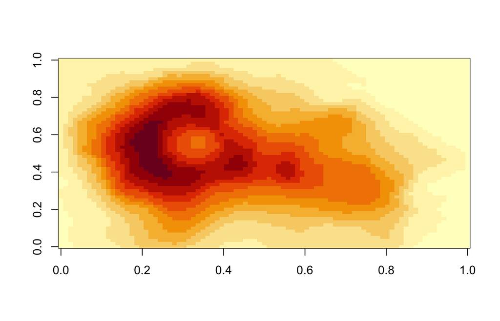

```r
# press the green triangle in the top right corner to see a volcano!
  image(volcano)
```

Code chunks can output multiple maps or information underneath below the code. When engaging with this document in RStudio, run the code chunk and view each output item by clicking between the small thumbnails. Try navigating between examples of topographic maps in the code chunk below!

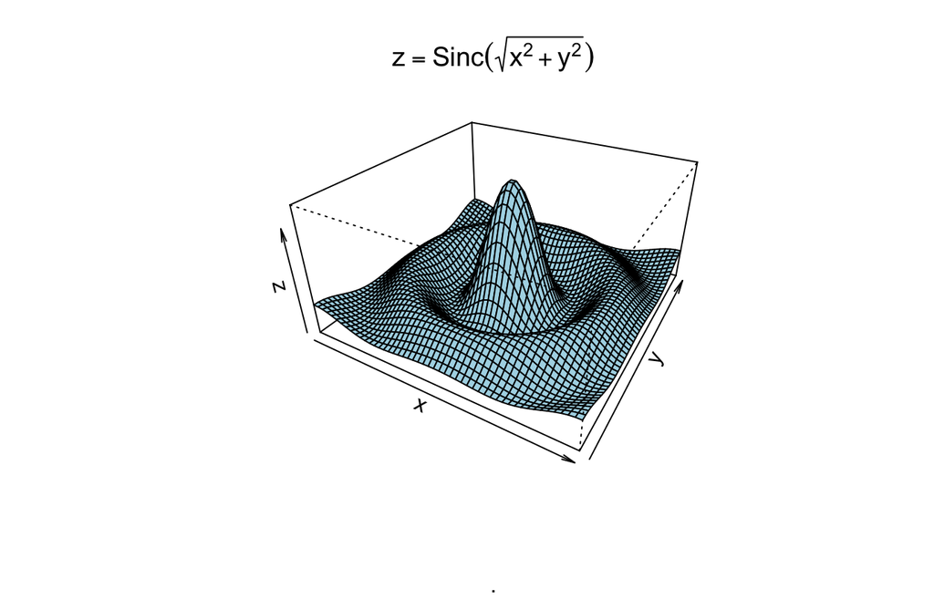

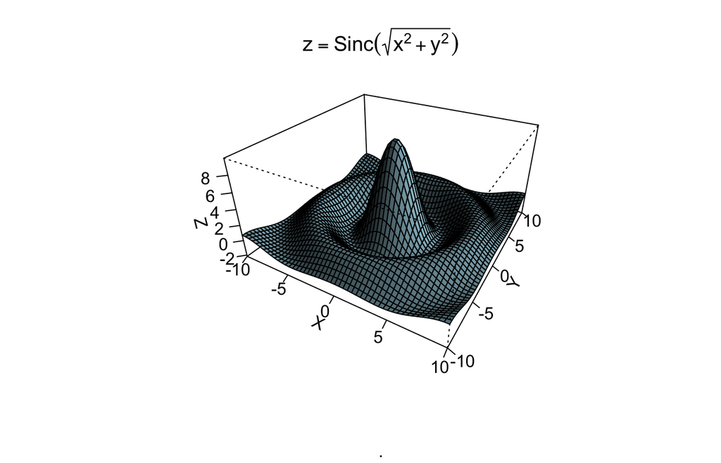

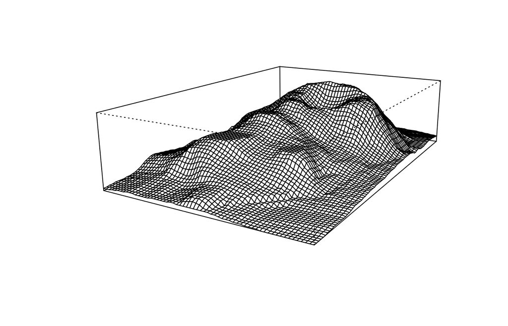

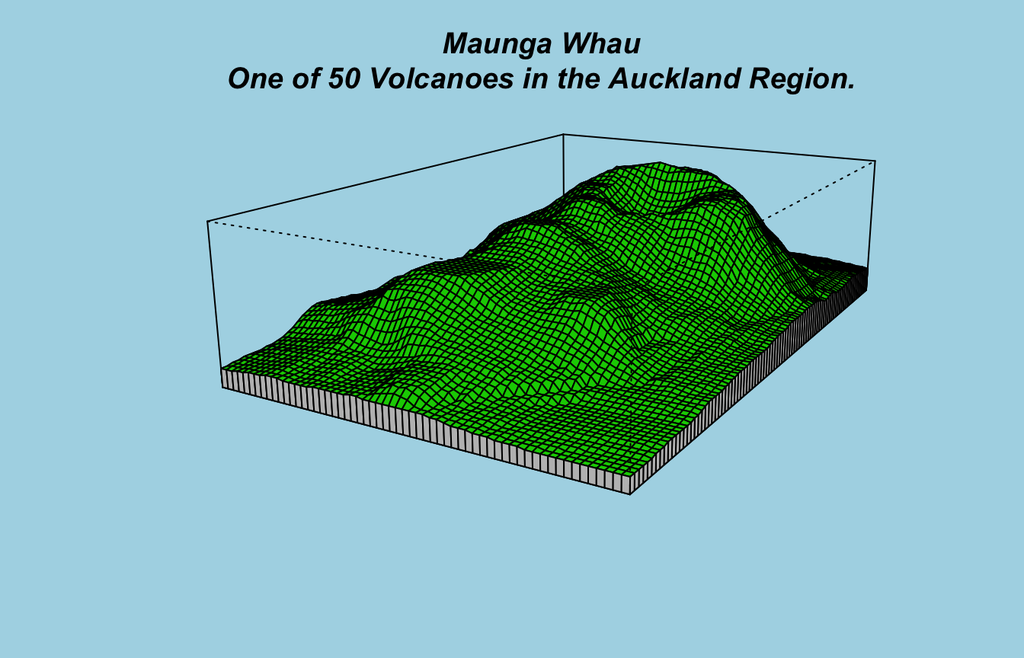

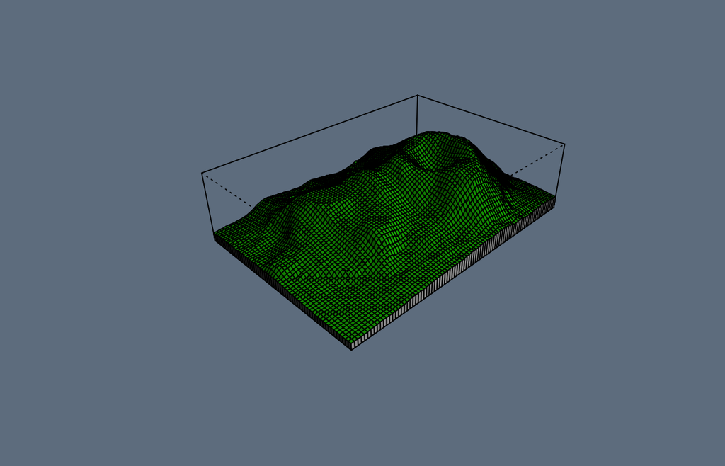

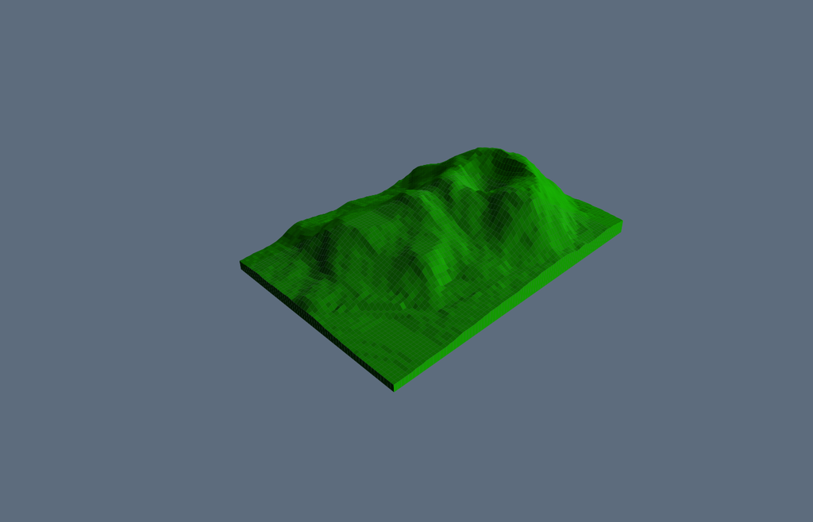

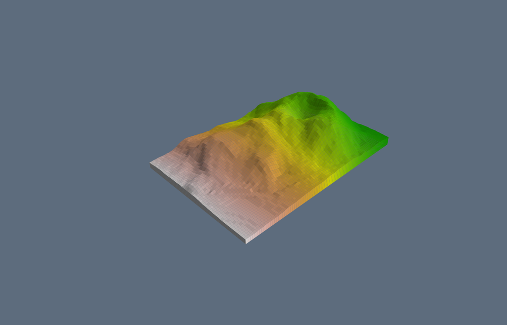

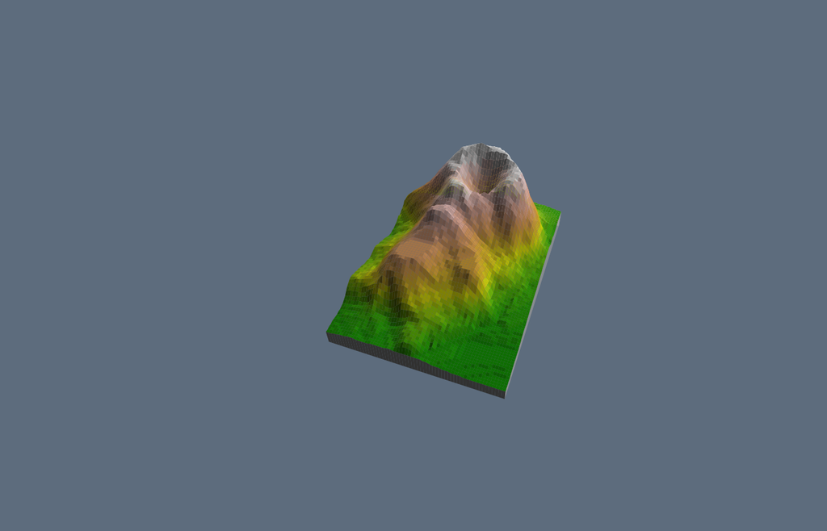

```r
# see several cool volcanos
  demo(persp)
```

The code chunks are meant to be run in the order they appear as you read, so do not hop around too much. If you begin getting errors, go up to the previous code chunk and press the “Run All Chunks Above” option (downward arrow and green bar). This should execute the document in order from the beginning and correct any errors. It may take a few minutes to complete!

# Workshop Overview -

This PAA 2026 Virtual Workshop will demonstrate the general process for downloading, processing, and integrating environmental data with population and/or health outcome data. Workshop topics will cover three broad categories:

1. basic concepts in spatial data management and usage (spatial data types, spatial data operations, geometric operations, coordinate reference systems, raster-vector interactions).
2. intermediate skills for importing US Census data using an API.
3. Intermediate skills and concepts for integrating high-frequency vector-based (gridded) and tabular environmental data with tabular and spatial longitudinal population data and individual level survey data.

## Goals and Outcomes

1. Participants will gain a working knowledge of basic and intermediate GIS data processing and integration, a working R script that they can implement within their own research endeavors, and references to additional R-based resources for further training.
2. The end result of this document are several use-case examples of workflows that generate analysis-ready data sets. Each include population or survey data that is successfully integrated with wildfire smoke measures at different spatial and temporal specificity.
3. Users can use code from this RMarkdown file and associated R scripts to create their own project workflows. Geographic areas, time frames, population/survey data, and other analytic aspects of the coding can be modified to fit the researcher’s use cases. With minor edits, the user can apply the same workflow to other high-frequency environmental data, such as heat, precipitation, or land coverage.
4. Users will have a list of additional online resources from CACHE and other reputable R coding and spatial data professionals.

## About the Instructor

My name is Alex Mikulas. I have a PhD in Community and Environmental Sociology from the University of Wisconsin-Madison, with a focus on spatial demography, geography, and inequality. I am the postdoctoral associate for the [Center for Aging, Health, & Environment (CACHE)](https://agingclimatehealth.org/) at the University of Colorado Boulder’s [Institute of Behavioral Science](https://ibs.colorado.edu/) (IBS). I am affiliated with the IBS [Population Program](https://ibs.colorado.edu/programs-and-centers/population/). I work closely with environmental sociologists and demographers, Dr. [Lori Hunter](https://ibsweb.colorado.edu/lori-hunter/) and Dr. [Deborah Balk](https://www.baruch.cuny.edu/profiles/faculty/Deborah-Balk). Drs. Hunter and Balk are CACHE Co-PIs.

## About CACHE

CACHE is an NIH/NIA funded virtual research center. Our purpose is to facilitate research and foster interdisciplinary collaborations between researchers working at the nexus of aging, health and environment. CACHE achieves these aims through targeted interdisciplinary training, information and resource sharing, and investments in research support.

- [**Newsletter**](http://eepurl.com/i7kp2g) with opportunities, resources, and events
- [**Code & Data**](https://agingclimatehealth.org/code-and-data/) Resources
- [**What Am I Reading?**](https://agingclimatehealth.org/what-am-i-reading/) research synthesis and briefs
- Regularly scheduled [**“under-the-hood”**](https://agingclimatehealth.org/cache-online-seminars/) virtual research seminars
- [**Training and Workshop content**](https://agingclimatehealth.org/workshops/)
- [**Working Groups**](https://agingclimatehealth.org/working-groups/)
- [**Demonstration Projects**](https://agingclimatehealth.org/demo-projects/)

CACHE is funded by the National Institute on Aging of the National Institutes of Health, award number 1R33AG104567-01 “CACHE: Supporting Interdisciplinary Inclusion of Context in Aging and Health Research.”

## Workshop Data Sources

This workshop uses the following population and survey data sources:

1. [**US Census Bureau American Community Survey 5-year estimates, 2014 - 2023**](https://www.census.gov/programs-surveys/acs.html): longitudinal survey of American households, available at course and fine spatial scales. Accessed via API using the `tidycensus` R package.
2. Example generated data of a multi-wave, longitudinal health study: Sample data generated for 1000 participants over three waves between 2015 and 2023.

These data will be integrated with the following wildfire smoke data:

1. [**Stanford Echolab Wildfire Smoke Plume Data**](https://www.stanfordecholab.com/wildfire_smoke): United states wildfire smoke estimates, contiguous US; 2006-2023; resolutions at the 10km grid, US county, US census tract, and US Zip Code levels.

# Part 1: Set Up Environment -

First we will establish the RStudio working environment by setting the correct file paths and loading the necessary packages. The .zip file consists of a single folder with all the required RMarkdown scripts, R scripts, data folders, output folders, and an RStudio Project file (PAA_VirtWorkshop_2026.Rproj). Do not change any folder organization within the zipped folder.

## Load Package Libraries

- First, load the necessary R packages for the entire analysis. These packages were already installed onto your machine prior to this workshop when you completed the workshop preparation materials.
- `pacman` is a package that easily installs updates, and loads packages in a single command.
- `here` is a package that uses uniform format for file directories, which ensures that the code is portable. This practice avoids hard-coding file paths, a common source of errors when sharing code.
- `tidyverse`, `lubridate`, `magrittr`, `broom`, `purr`, `haven`, and `janitor` are data wrangling packages.
- `sf` is the primary package for reading, editing, and wrangling spatial data. `rmapshaper` helps with simplifying complex geographies.
- `raster`, `terra`, `stars`, and `exactextractr` are packages to handle and manipulate raster data and efficiently access high-frequency raster data.
- `slider` helps compute running averages.
- `spdep`, and `spatialreg` are used for spatial regression analysis.
- `tmap` is a simple mapping package.

```r
# clear graphics demonstration objects
  rm(list = ls())

# install pacman package
  # install.packages("pacman")
  library(pacman)

# use pacman::p_load() to load necessary packages
  p_load(here, # file directory helper enabling cross platform directory uses
         tidyverse, lubridate, magrittr, broom, purrr, haven, janitor, # data management
         sf, raster, stars, exactextractr, terra, rmapshaper, # spatial processing
         slider, # running averages
         spdep, spatialreg, # spatial analysis
         tidycensus, ipumsr, tigris, # external census data
         stargazer, knitr, # tables/reports
         tmap # simple mapping
        )
```

## Set Working Directory

The `here::i_am()` command sets the root directory path for whichever location that the stated file is located. Then, the `here()` command will show you your current working directory. This is the local folder location where all your folders, files, data, and scripts are stored and called throughout the analysis.

```r
# set the working directory
  here::i_am("Environment_and_Population_Data.Rmd")
  here() # confirm location is correct
```

```
## [1] "/Users/workalex/Library/CloudStorage/Sync/2_Alex_Work/CACHE/Trainings/PAA_Workshop_October_2026"
```

# Part 2: Primer for Spatial Data -

## What is Spatial Data?

Spatial data is any type of data that is associated to a specific location, or “spatially located”. Most data is spatial! It just may not have the level of specificity, or correct data fields, to use in formal spatial data processing or analysis (known as GIS, or Geographic Information System). But data does have correct GIS formatting and structure, it can be referenced to, associated with, and integrated with other spatial data sets.

If a data set is “spatial” then it has information (variables, metadata, etc.) about the location and shape of the cases in the data. Survey data may have a field with the address of the respondent, which can be converted to latitude and longitude spatial data. Aggregated county data may have the FIPS code for each county, which can be merged with a data file describing the shape of the county. Files that describe the shape of geographic features (points, lines, polygons) are called shapefiles.

## Vector Data

Vector data are any data that have an explicit shape and location associated with them. Examples include polygons, like counties and census tracts, lines, like rivers and roads, or points, like addresses. Most vector data is formatted as a shapefile, which comes as a folder with a collection of files used to create the metadata required for mapping geographic data. When you read a shapefile into R, use the `st_read()` function, and indicate the .shp file in the `file =` parameter.

In R, a shapefile looks like a simple data.frame object. But, its R object class is `sf`, or Simple Features. This means the data set has additional fields and metadata that allow you to represent it geographically and perform spatial operations. The shape and location of the rows or observations in a shapefile are described with a “*geometry*” or “*geom*” column, which have specially formatted data representing an ordered list of one or more point coordinates (longitude and latitude).

**Point data** are the most simple type of vector data. Let’s map all the airports in Wisconsin, and then examine the underlying dataframe.

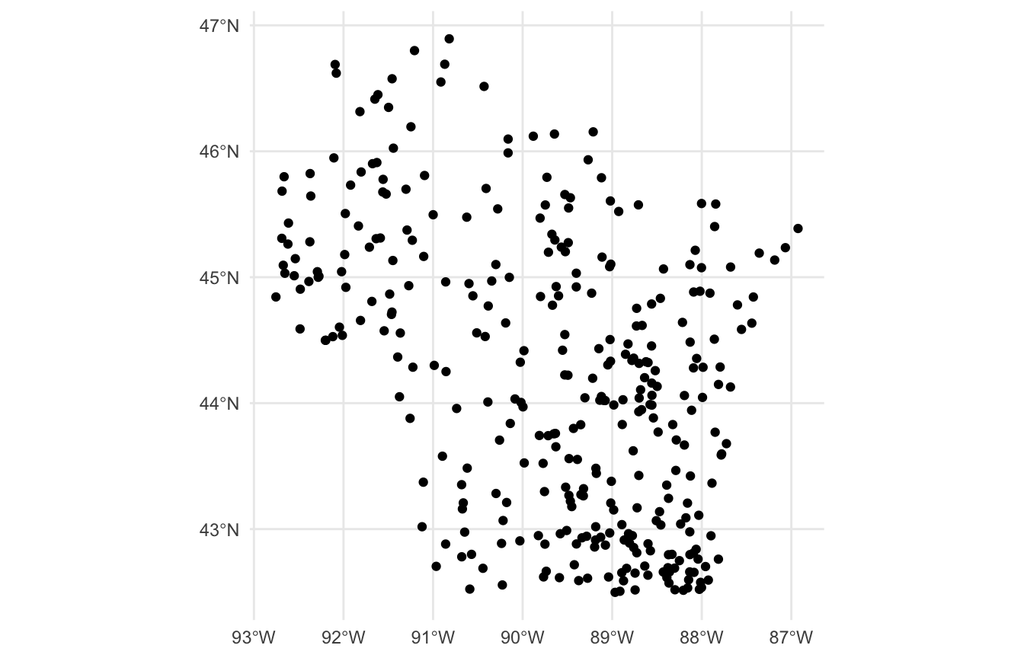

```r
  ggplot() +
    geom_sf(data = wi_airports) +
    theme_minimal()
```

```r
  head(wi_airports)
```

|  | STATEFP | ANSICODE | POINTID | FULLNAME | MTFCC | geometry |
| --- | --- | --- | --- | --- | --- | --- |
| 1 | 55 | NA | 11015504306469 | Clearwater Aero Estates Arprt | K2451 |  |
| 2 | 55 | NA | 11015504306475 | Wood Arprt | K2451 |  |
| 3 | 55 | NA | 11015504306489 | Log Cabin Arprt | K2451 |  |
| 4 | 55 | NA | 11015504306490 | Bulldog Ranch Arprt | K2451 |  |
| 5 | 55 | NA | 11015504306491 | Old Dairy Arprt | K2451 |  |
| 6 | 55 | NA | 11015504306494 | New Holstein Municipal Arprt | K2451 |  |

```r
  str(wi_airports)
```

```
## Classes 'sf' and 'data.frame':   335 obs. of  6 variables:
##  $ STATEFP : chr  "55" "55" "55" "55" ...
##  $ ANSICODE: chr  NA NA NA NA ...
##  $ POINTID : chr  "11015504306469" "11015504306475" "11015504306489" "11015504306490" ...
##  $ FULLNAME: chr  "Clearwater Aero Estates Arprt" "Wood Arprt" "Log Cabin Arprt" "Bulldog Ranch Arprt" ...
##  $ MTFCC   : chr  "K2451" "K2451" "K2451" "K2451" ...
##  $ geometry:sfc_POINT of length 335; first list element:  'XY' num  -89.7 43.8
##  - attr(*, "sf_column")= chr "geometry"
##  - attr(*, "agr")= Factor w/ 3 levels "constant","aggregate",..: NA NA NA NA NA
##   ..- attr(*, "names")= chr [1:5] "STATEFP" "ANSICODE" "POINTID" "FULLNAME" ...
##  - attr(*, "tigris")= chr "point_landmark"
```

Note the various information available from the `head()` command and `str()` command. We can tell that that each airport has its own row in the data. The data is formatted as a a “simple feature” collection, meaning it has metadata that defines it as a map-able spatial data set. Each row has a *geometry* column with the longitude/latitude. POINT indicates that the rows in the data represent a single geographic coordinate.

**Line data** represent a series of geographic coordinates that are in a certain order - like a children’s connect the dot drawing activity. Let’s map the main interstates and large roads in Wisconsin, take look at the data structure, and investigate a *geometry* column.

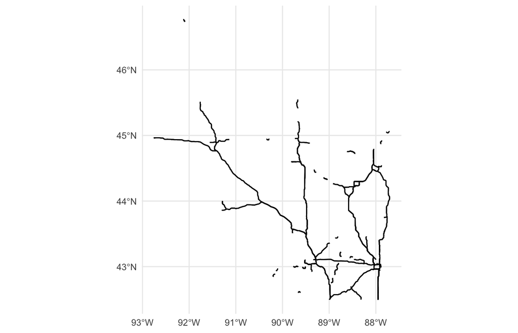

```r
  ggplot() +
    geom_sf(data = wi_roads) +
    theme_minimal()
```

```r
  str(wi_roads)
```

```
## Classes 'sf' and 'data.frame':   394 obs. of  5 variables:
##  $ LINEARID: chr  "1108296451323" "1108296451337" "1108296492013" "1108296492023" ...
##  $ FULLNAME: chr  "State Hwy 67" "State Hwy 67" "State Hwy 55" "State Hwy 55" ...
##  $ RTTYP   : chr  "S" "S" "S" "S" ...
##  $ MTFCC   : chr  "S1100" "S1100" "S1100" "S1100" ...
##  $ geometry:sfc_LINESTRING of length 394; first list element:  'XY' num [1:5, 1:2] -88.5 -88.5 -88.5 -88.5 -88.5 ...
##  - attr(*, "sf_column")= chr "geometry"
##  - attr(*, "agr")= Factor w/ 3 levels "constant","aggregate",..: NA NA NA NA
##   ..- attr(*, "names")= chr [1:4] "LINEARID" "FULLNAME" "RTTYP" "MTFCC"
##  - attr(*, "tigris")= chr "primary_roads"
```

Each road has one or more rows in the data representing road segments. The geometry column indicates that the data is a series of longitude/latitude points connected in a specific order. Use the command `view(wi_roads)` to explore the dataframe and the geometry column. Note that the geometry column is a `list` object that stores long/lat data in a specific order.

**Polygon data** is similar to line data, but the dots connect to form a polygon. Some boundaries are more complicated than a simple polygon. For instance, the Apostle Islands in Lake Superior are part of Wisconsin’s Ashland and Bayfield counties. To capture the multiple polygons that make up these counties, the geometry column indicates MULTIPOLYGON, and is formatted to connect certain groups of long/lats in a certain order. Let’s take a look at a few examples.

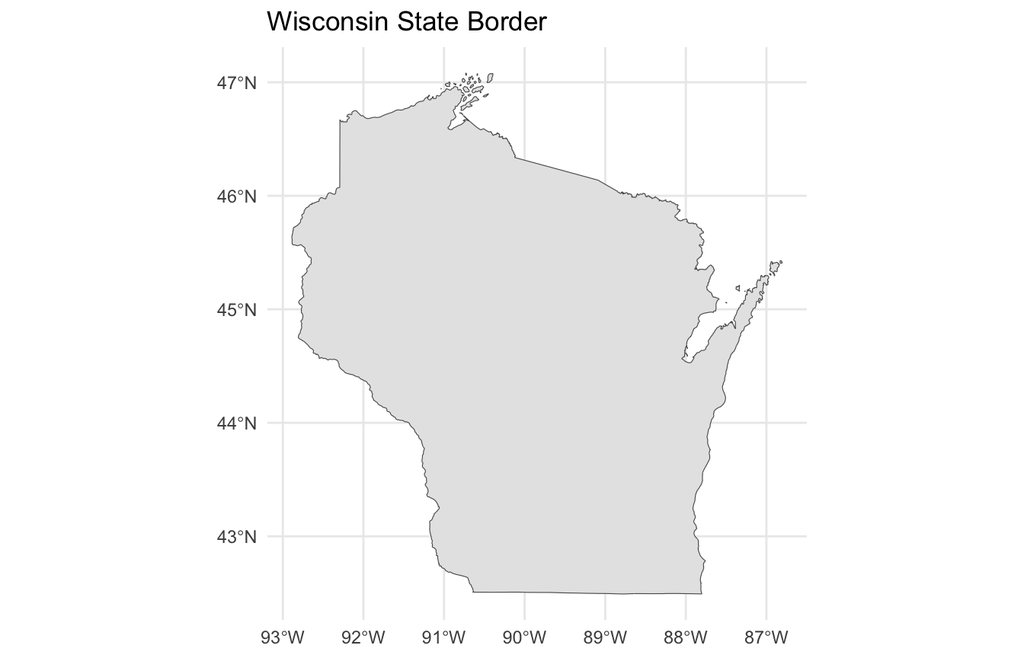

```r
  ggplot() +
    geom_sf(data = wi) +
    labs(title = "Wisconsin State Border") +
    theme_minimal()
```

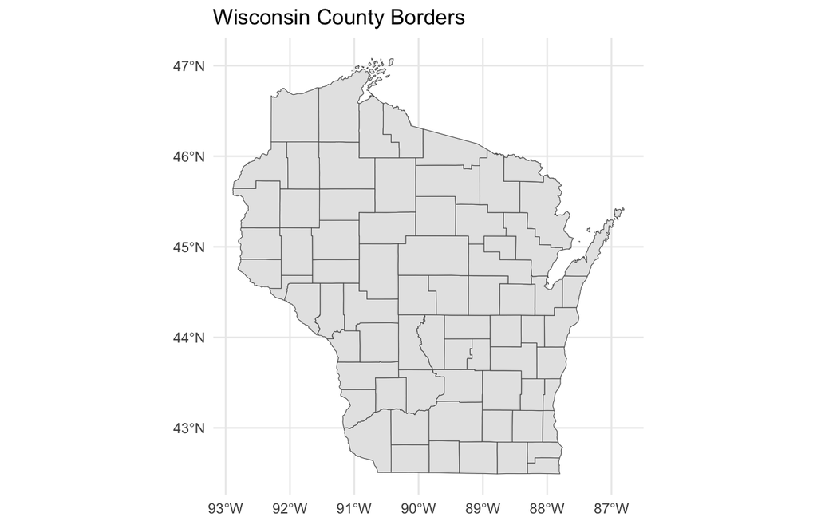

```r
  ggplot() +
    geom_sf(data = wi_counties) +
    labs(title = "Wisconsin County Borders") +
    theme_minimal()
```

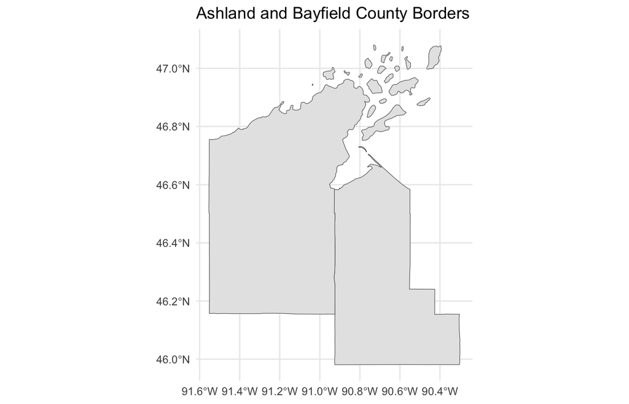

```r
  ggplot() +
    geom_sf(data = ash_bay_counties) +
    labs(title = "Ashland and Bayfield County Borders") +
    theme_minimal()
```

Again, use the `View(ash_bay_counties)` command in the console to see the structure of the data for these counties. The geometry column is formatted as a list of lists, each with a set of long/lats denoting the boundaries of every distinct polygon in the county.

**Gridded data** is a special kind of vector data. It does not use administrative boundaries for each of the rows in the data. Instead, it uses a uniform grid that completely covers a large swath of area. Each cell in the grid is the same size and is represented as one row in a shapefile. Below, we map a shapefile that contains cartographic boundary data for a 10 kilometer grid that covers the state of Wisconsin.

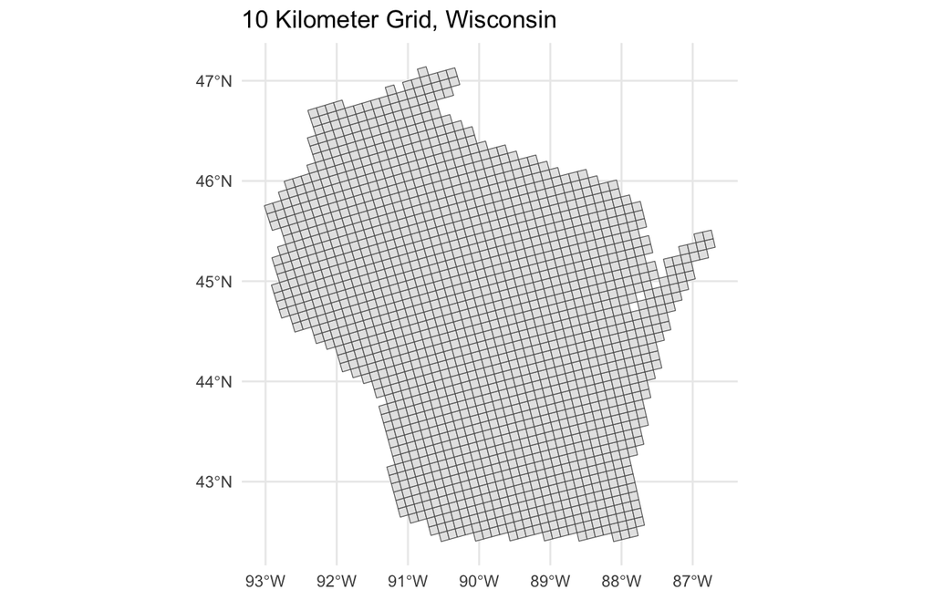

```r
  ggplot() +
    geom_sf(data = wi_10km) +
    labs(title = "10 Kilometer Grid, Wisconsin") +
    theme_minimal()
```

Using `ggplot` or other cartographic mapping packages, R can easily map vector data, and overlay multiple vector layers to represent a more detailed map. Here is a basic example, and more complex maps will appear later in the workshop.

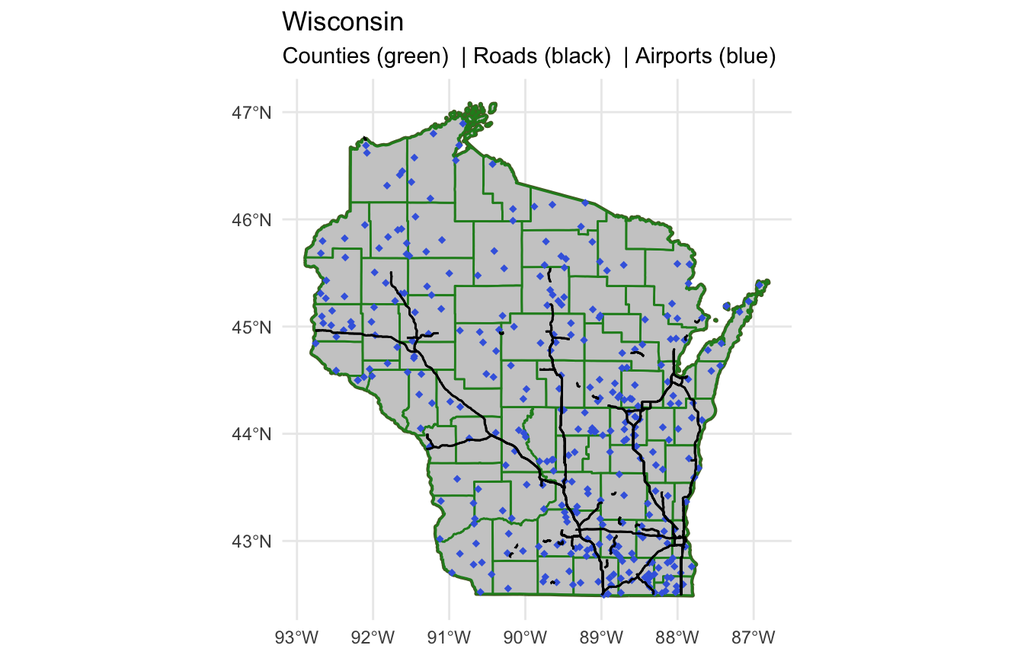

```r
# plot wisconsin vector data types
  ggplot() +
    geom_sf(data = wi,
            color = "darkolivegreen",
            linewidth = 1) +
    geom_sf(data = wi_counties,
            color = "forestgreen",
            linewidth = 0.5,
            fill = "grey80") +
    geom_sf(data = wi_airports,
            color = "royalblue",
            shape = 18) +
    geom_sf(data = wi_roads,
            color = "black",
            linewidth = 0.5) +
    labs(title = "Wisconsin",
         subtitle = "Counties (green)  | Roads (black)  | Airports (blue)") +
    theme_minimal()
```

### Vector attribute data

Shapefiles often include attribute data for each row of geography in a spatial data set. These are tabular columns akin to those in a standard dataframe. Attribute data can be character-based geographic identifiers (like county names or codes such as FIPS) or any other data that is associated with each row of the point, line, or polygon geometry. County level population data, for instance, might be included as attribute data columns in a county shapefile. Let’s map the attribute data that measure cthe county land area in square meters, ALAND, data using ggplot. Then lets map the attribute variable attribute_1, of the 10km gridded data. Both maps are examples of choropleth maps, which display continuous variable values for each polygon as a color shade along a spectrum.

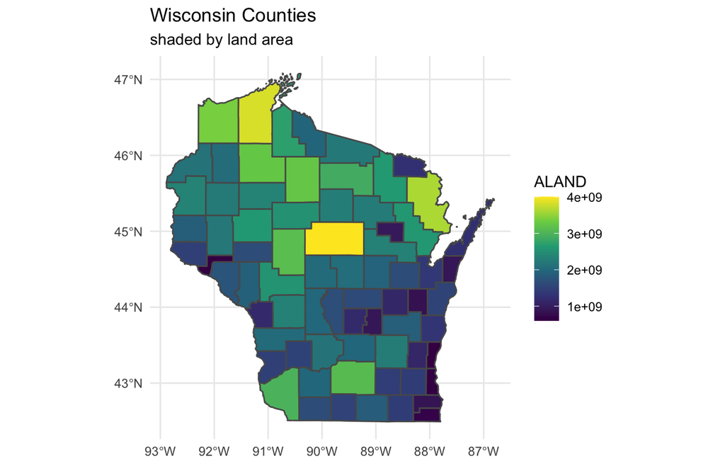

```r
# plot land area attribute
  ggplot() +
    geom_sf(data = wi_counties,
            aes(fill = ALAND),
            linewidth = 0.5) +
    scale_fill_viridis_c() +
    labs(title = "Wisconsin Counties",
         subtitle = "shaded by land area") +
    theme_minimal()
```

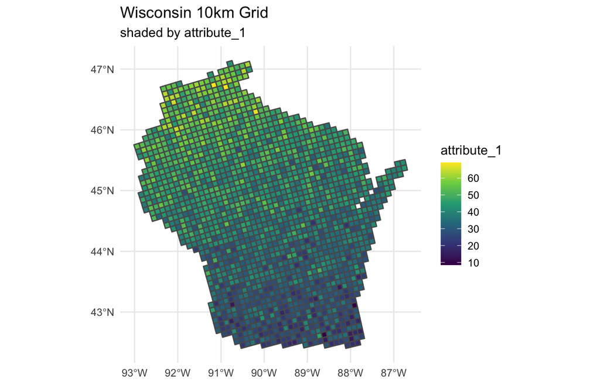

```r
  ggplot() +
    geom_sf(data = wi_10km,
            aes(fill = attribute_1),
            linewidth = 0.5) +
    scale_fill_viridis_c() +
    labs(title = "Wisconsin 10km Grid",
         subtitle = "shaded by attribute_1") +
    theme_minimal()
```

## Raster Data (continuous, high frequency, spatio-temporal)

Raster data are continuous forms of spatial data. Rather than being a distinct shape or point, each row in the data represent a single measure of a variable for a specific section in a grid. Raster data is very similar to vector gridded data, but at a much more detailed spatial scale. Rather than a large grid, raster data is better conceptualized as an image with pixels. Each pixel in the large image is a datapoint for the small area of land that it covers. A raster data set for a single variable for a single moment in time is called a **rasterlayer**.

There are several packages that make working with raster and RasterBrick data easier. `raster`, `stars`, and `terra` are the most common and universal for processing and raster data management. `exactextractr` is best for accessing specific layers and pixels out of large RasterBricks.

This workshop is not intended to cover raster data processing and integration. Instead, we will focus on gridded vector based high-frequency data, which will demonstrate the utility - and limitations - of gridded data. Below are CACHE affiliated resources to learn more about processing raster-based environmental data.

### CACHE resources on raster data processing

- [**exactextractr R Package**](https://github.com/isciences/exactextractr/tree/master) - efficient functions for integrating raster and vector data.
- [**Measuring Heat for Population Research**](https://agingclimatehealth.org/wp-content/uploads/2026/05/For-Website_MIM-PAA2026-Agenda-2.pdf) - materials from a 2026 PAA member initiated meeting and workshop
- [**Daily Temperature Processing and Analysis**](https://agingclimatehealth.org/daily-temperature-data-processing-and-analysis-an-example-for-new-york-city/) by Selene Ozdogan
- [**Severe Heat Days Using the Universal Thermal Comfort Index**](https://agingclimatehealth.org/severe-heat-days-using-the-universal-thermal-comfort-index/) by Marcial Yangali
- [**Joining ACAG Annual Estimates of PM2.5 with Social Determinants of Health (SDOH) data**](https://agingclimatehealth.org/joining-acag-annual-estimates-of-pm2-5-with-social-determinants-of-health-sdoh-data/) by Zoé Haskell-Craig and Priyanka deSouza

## Spatial Metadata

What differentiates regular tabular data - even tabular data with a longitude and latitude colums - from spatial data is that spatial data has particular metadata associated with the data file: the coordinate reference system and the shapefile projection. Both provide important information for how your softward should read, interpret, and visualize the latitude and longitude data in the geometry column.

### Coordinate Reference Systems (CRS)

A CRS is like a shared language for interpreting geographic coordinates. When spatial data sets have the same CRS metadata, they both interpret the geometry columns in the same way. Thus, they are able to “talk” to one another because they have a shared understanding of the geographic data points in the shapefile. Therefore, when you perform a spatial data operation or geometric operation on two different shapefiles, they are “layered” correctly and any overlapping or intersecting geometries can be accurately computed.

If two shapefiles do not have the same CRS, they will not be “layered” correctly during geocomputation. Often, this will produce an error message. But, in some cases, the procedure will execute on misaligned geometries, created faulty data. Let’s examine the CRS metadata of the `wi_counties` shapefile.

```r
# inspect a sf object CRS
  st_crs(wi_counties)
```

```
## Coordinate Reference System:
##   User input: NAD83
##   wkt:
## GEOGCRS["NAD83",
##     DATUM["North American Datum 1983",
##         ELLIPSOID["GRS 1980",6378137,298.257222101,
##             LENGTHUNIT["metre",1]]],
##     PRIMEM["Greenwich",0,
##         ANGLEUNIT["degree",0.0174532925199433]],
##     CS[ellipsoidal,2],
##         AXIS["latitude",north,
##             ORDER[1],
##             ANGLEUNIT["degree",0.0174532925199433]],
##         AXIS["longitude",east,
##             ORDER[2],
##             ANGLEUNIT["degree",0.0174532925199433]],
##     ID["EPSG",4269]]
```

Note the CRS metadata has multiple parameters that define how the geometries are meant to be read and what the projection is.

### Shapefile Projections

A shapefile’s projection are the parameters for how the mapping software will visualize your data. While a CRS helps GIS software interpret shapefile geometries, the projection tells the GIS software where the geometries are meant to be displayed when mapped. Because the earth is round, but we view maps on flat, 2-dimensional screens, the geographic shapes will always have some level of distortion. A shapefile projections sets the parameters for where to center the data on the screen, and how to distort the map boundaries to display in a flat screen. Consider the examples below of the same shapefile but visualized using different CRS and projection metadata.

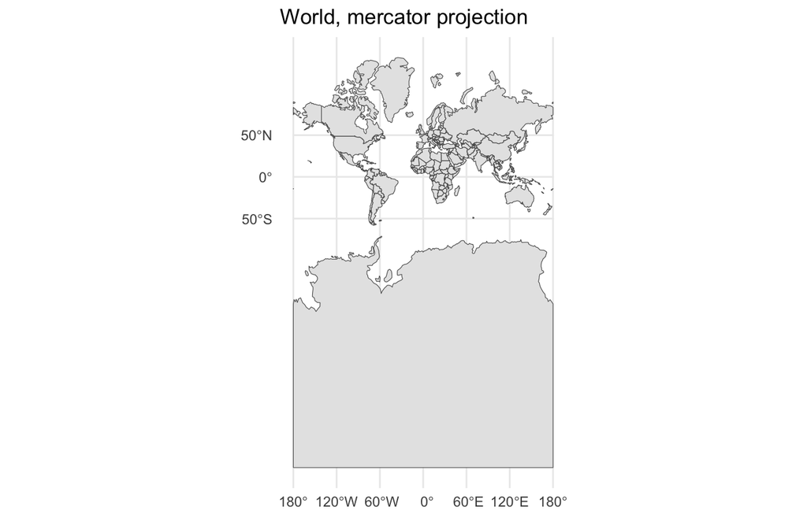

```r
# plot Mercator projection
  world_mercator <- st_transform(world, crs = 3857)

  ggplot() +
    geom_sf(data = world_mercator) +
    labs(title = "World, mercator projection") +
    theme_minimal()
```

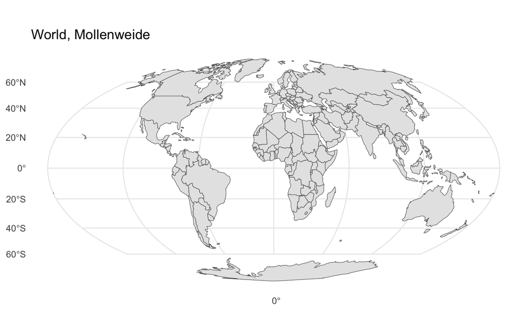

```r
# assign Mollweide projection parameter to world
  world_mollweide = st_transform(world, crs = "+proj=moll")

  ggplot() +
    geom_sf(data = world_mollweide) +
    labs(title = "World, Mollenweide") +
  theme_minimal()
```

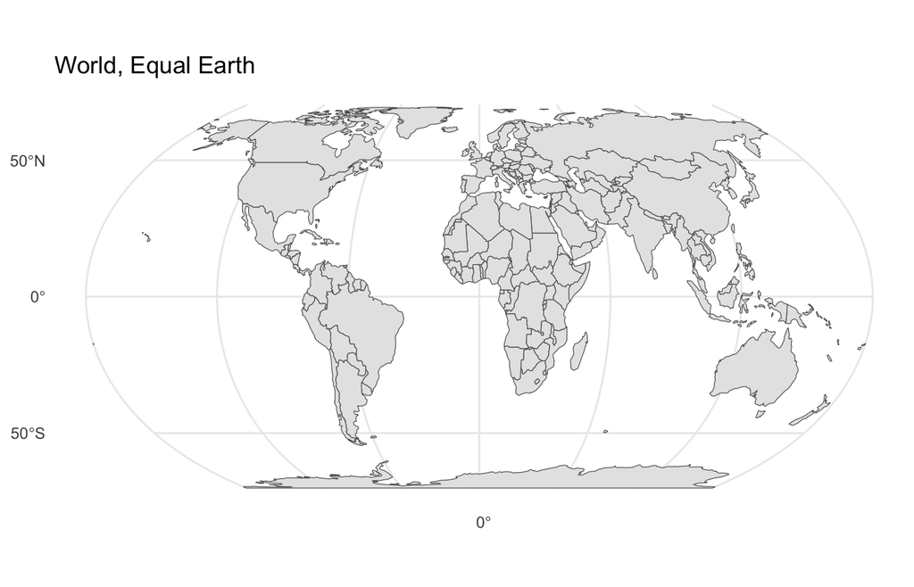

```r
# assign equal earth projection
  world_ea <- st_transform(world, crs = 8857)

  ggplot() +
    geom_sf(data = world_ea) +
    labs(title = "World, Equal Earth") +
  theme_minimal()
```

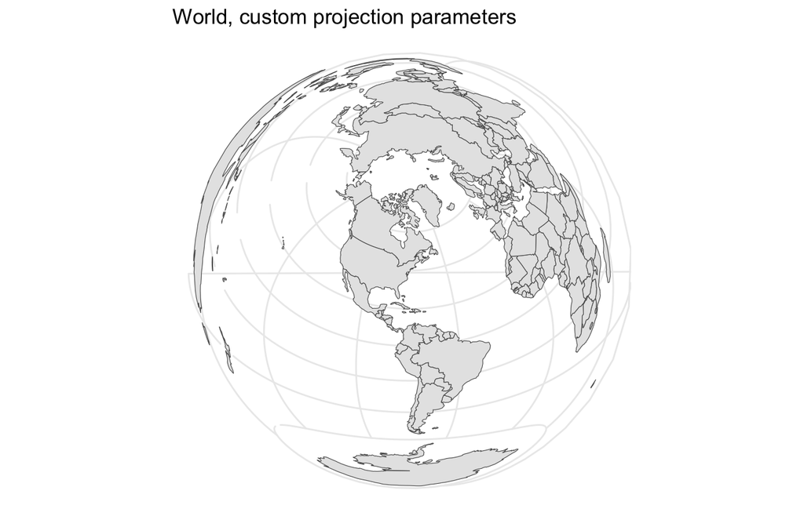

```r
# assign custom projection to world
  world_cust = st_transform(world, crs = "+proj=laea +x_0=0 +y_0=0 +lon_0=-74 +lat_0=40")

  ggplot() +
    geom_sf(data = world_cust) +
    labs(title = "World, custom projection parameters") +
    theme_minimal()
```

Projections are the culprit for why Greenland, for example, often looks so large on a flattened map, or why the US can appear to have a flat northern border, or a curved northern border (see the [latest controversy](https://news.un.org/en/story/2026/09/1168284) over [official projection standards](https://www.aljazeera.com/news/2026/9/5/how-big-is-africa-really-why-the-un-voted-to-change-the-world-map) at the United Nations).

### Changing CRS and Projections

Finally, mapping functions like ggplot will automatically transform and re-project all shapefiles used in the creation of the figure with a uniform projection. This is helpful for cartographic purposes, but do not assume that all shapefiles have the same CRS because they look accurate in a ggplot figure.

It is best to check each shapefile and re-project any errant CRS settings so all shapefiles in your project have the same CRS. You can convert the CRS of any `sf` R object with the command `st_transform()`. A uniform CRS across all your shapefiles is critical when performing spatial data operations and geometric operations, which are discussed in the next sections.

```r
# save a CRS setting from a given sf object (here, wi_counties) as standalone R object
  my_special_crs_object <- st_crs(wi_counties)

# apply your crs object to other sf objects
  wi_airports <- st_transform(wi_airports, crs = my_special_crs_object)

# confirm that your county and airport sf objects have the same CRS
  st_crs(wi_counties) == st_crs(wi_airports)
```

```
## [1] TRUE
```

Some CRSs and projections are best suited for large areas like states or countries, while others are best suited for smaller areas like blocks or tracts. There is not a universal CRS/projection or a single correct CRS/projection. Instead, choose those that are best suited for your project based on the geographic scope, the location of your geometries, and the type of mapping you intend. If you are importing shapefiles from a reputable, standardized source like the US Census, the existing CRS is usually appropriate. Learn more about [when to re-project or change your CRS](https://r.geocompx.org/reproj-geo-data#whenproject). If you need to change your CRS, see the [R package crsuggest](https://github.com/walkerke/crsuggesthttps://github.com/walkerke/crsuggest) for help with deciding an appropriate choice.

## Spatial Data Operations

The power of spatial data is not just that you can represent it cartographically. The underlying spatial structure of the data (coordinates in space) allows for data sets that do not share linking IDs or unique keys to integrate based on their spatial relationships. For example, the `wi_airports` data cannot link with the `wi_counties` data because neither have a shared common identifier. The `wi_airports` data does not, for example have an address or county variable. But using the spatial structure of both data, we can locate airports in space and counties in space, and then associate the data based on where each county and each airport is in relation to one another. This is an example of a **spatial data operation**, where the location and shape of the data sets are used to modify or enrich one another.

**Example: Create a variable for the number of airports per county in Wisconsin**. We can do this by mutating a new variable in the `wi_counties` data set that performs the spatial data operation `st_intersects`.

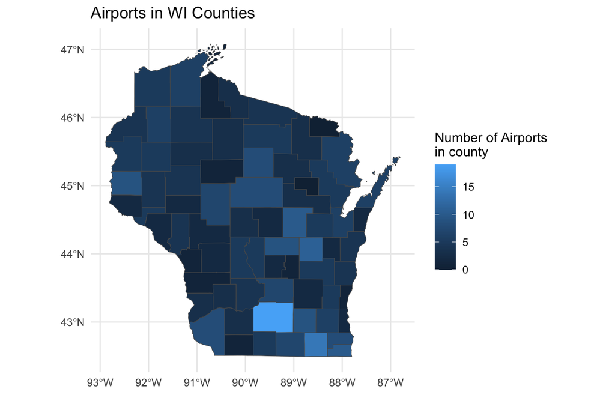

```r
# intersect airports into counties
  wi_counties  <- wi_counties |>
    mutate(n_airports = lengths(st_intersects(wi_counties, wi_airports)))

# plot county-level variable for number of airports
  ggplot() +
    geom_sf(data = wi_counties,
            aes(fill = n_airports)) +
    labs(title = "Airports in WI Counties",
         fill = "Number of Airports\nin county") +
    theme_minimal()
```

**Example: Assign a county FIPS to each airport**. We can use another spatial data operation to enrich the `wi_airports` data set. We will create a simplified counties dataframe that is just the county FIPS code and the spatial geometry. Then, we will perform a spatial join between the `wi_airports` and the temporary county shapefile. Now the `wi_airports` data has a GEOID column denoting the county that each airport is in.

```r
# make a temp sf copunty file with only GEOID attribute column
  temp <- wi_counties |>
    dplyr::select(GEOID)

# join temp attributes (just GEOID) to airports sf object
  wi_airports <- st_join(wi_airports, temp)

# inspect column names to confirm that GEOID joined to wi_airports
  colnames(wi_airports)
```

```
## [1] "STATEFP"  "ANSICODE" "POINTID"  "FULLNAME" "MTFCC"    "GEOID"    "geometry"
```

There are many different types of spatial data operations in the `sf` package. See the list of resources at the end of Part 1 document for a deeper dive into spatial data operations.

## Geometric Operations

The geometry column in a shapefile described the spatial extent of each observation in your data. Sometimes, it is necessary to edit the geometries in your data based on project needs. For instance, you may need to add a buffer radius to point data, or analyze only the intersecting areas of two polygon shapefiles. These can be accomplished through **geometric operations**, or processes that add to or edit vertices in the geometry column of shapefiles.

### Alter geometries

Some geometric operations drastically alter the shape of geometries.

**Example: convert a point data set to a polygon with a radius of 5 kilometers.** First, check the CRS of the point shapefile to see the units used with the `st_crs()` command. Then use the `st_buffer()` command to convert the point geometries to polygons. View the geometry types before and after with the `str()` command.

```r
  st_crs(wi_airports)
```

```
## Coordinate Reference System:
##   User input: NAD83
##   wkt:
## GEOGCRS["NAD83",
##     DATUM["North American Datum 1983",
##         ELLIPSOID["GRS 1980",6378137,298.257222101,
##             LENGTHUNIT["metre",1]]],
##     PRIMEM["Greenwich",0,
##         ANGLEUNIT["degree",0.0174532925199433]],
##     CS[ellipsoidal,2],
##         AXIS["latitude",north,
##             ORDER[1],
##             ANGLEUNIT["degree",0.0174532925199433]],
##         AXIS["longitude",east,
##             ORDER[2],
##             ANGLEUNIT["degree",0.0174532925199433]],
##     ID["EPSG",4269]]
```

```r
  str(wi_airports)
```

```
## Classes 'sf' and 'data.frame':   335 obs. of  7 variables:
##  $ STATEFP : chr  "55" "55" "55" "55" ...
##  $ ANSICODE: chr  NA NA NA NA ...
##  $ POINTID : chr  "11015504306469" "11015504306475" "11015504306489" "11015504306490" ...
##  $ FULLNAME: chr  "Clearwater Aero Estates Arprt" "Wood Arprt" "Log Cabin Arprt" "Bulldog Ranch Arprt" ...
##  $ MTFCC   : chr  "K2451" "K2451" "K2451" "K2451" ...
##  $ GEOID   : chr  "55001" "55001" "55011" "55001" ...
##  $ geometry:sfc_POINT of length 335; first list element:  'XY' num  -89.7 43.8
##  - attr(*, "sf_column")= chr "geometry"
##  - attr(*, "agr")= Factor w/ 3 levels "constant","aggregate",..: NA NA NA NA NA NA
##   ..- attr(*, "names")= chr [1:6] "STATEFP" "ANSICODE" "POINTID" "FULLNAME" ...
```

```r
# 5000 meter radius buffer
  wi_airport_buffer <- st_buffer(wi_airports, 5000)

  str(wi_airport_buffer)
```

```
## Classes 'sf' and 'data.frame':   335 obs. of  7 variables:
##  $ STATEFP : chr  "55" "55" "55" "55" ...
##  $ ANSICODE: chr  NA NA NA NA ...
##  $ POINTID : chr  "11015504306469" "11015504306475" "11015504306489" "11015504306490" ...
##  $ FULLNAME: chr  "Clearwater Aero Estates Arprt" "Wood Arprt" "Log Cabin Arprt" "Bulldog Ranch Arprt" ...
##  $ MTFCC   : chr  "K2451" "K2451" "K2451" "K2451" ...
##  $ GEOID   : chr  "55001" "55001" "55011" "55001" ...
##  $ geometry:sfc_POLYGON of length 335; first list element: List of 1
##   ..$ : num [1:821, 1:2] -89.7 -89.7 -89.7 -89.7 -89.7 ...
##   ..- attr(*, "class")= chr [1:3] "XY" "POLYGON" "sfg"
##  - attr(*, "sf_column")= chr "geometry"
##  - attr(*, "agr")= Factor w/ 3 levels "constant","aggregate",..: NA NA NA NA NA NA
##   ..- attr(*, "names")= chr [1:6] "STATEFP" "ANSICODE" "POINTID" "FULLNAME" ...
```

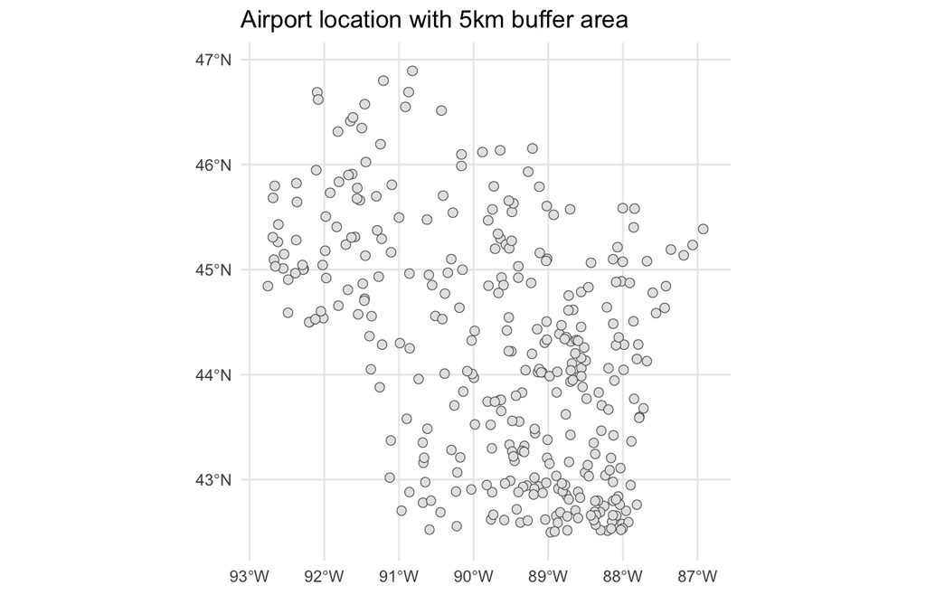

```r
  ggplot() +
    geom_sf(data = wi_airport_buffer) +
    labs(title = "Airport location with 5km buffer area") +
    theme_minimal()
```

**Example: reduce polygon data to point data.** `st_centroid` converts polygon geometry to the geometric point of the polygon. `st_point_on_survace` converts polygon geometry to a point that exits within the boundaries of the polygon, attempting to be near the centroid. This is a useful option if your polygons are shaped in such a way that the geometric centroid falls outside of the borders of the polygon geometry (ie: a shape like the sliver of a moon).

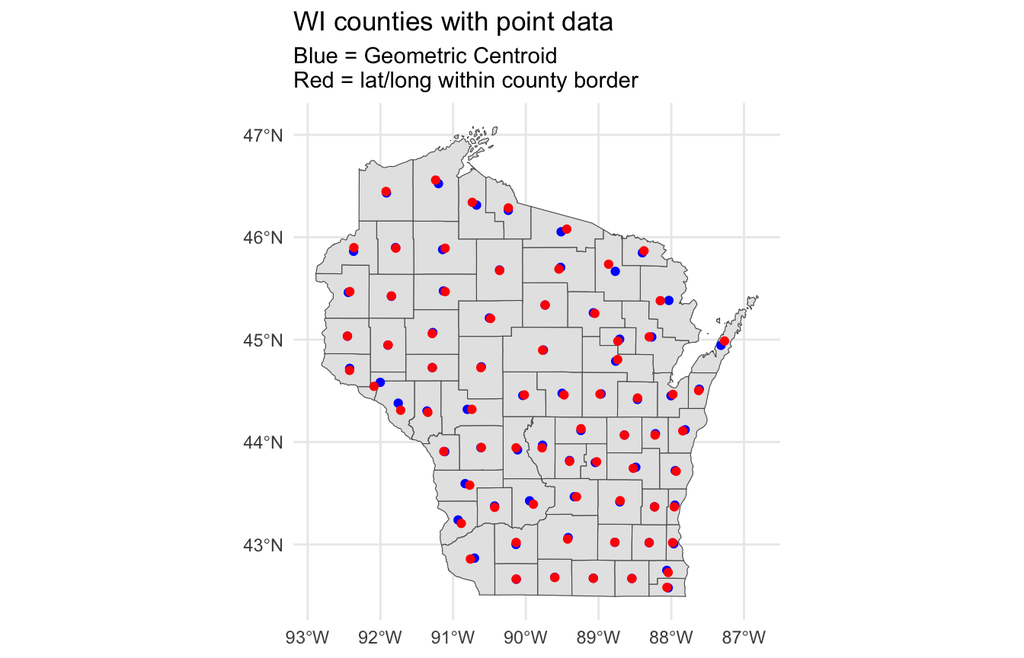

```r
  wi_county_points1 <- st_centroid(wi_counties)

  wi_county_points2 <- st_point_on_surface(wi_counties)

  ggplot() +
  # background county layer
    geom_sf(data = wi_counties) +
  # centroid layer
    geom_sf(data = wi_county_points1,
            color = "blue") +
  # point-in-poly layer
    geom_sf(data = wi_county_points2,
            color = "red") +
    labs(title = "WI counties with point data",
         subtitle = "Blue = Geometric Centroid\nRed = lat/long within county border") +
    theme_minimal()
```

### Simplify or repair geometries

Other geometric operations edit and repair the shape of geometries.

**Example: Simplify geometries.** Sometimes, vector data is extremely detailed (see the [coastline paradox](https://en.wikipedia.org/wiki/Coastline_paradox)…). Certain shapefiles may have a high degree of cartographic generalization, where the polygon and line geometries may have far to many vertices than are required for your analysis or mapping goals. When you are working with large spatial data sets, high cartographic generalization can consume computing power and memory because the geometry column may have thousands of lat/long coordinates per row.

One solution is to simplify, or generalize, your shapefile by removing vertices in your geometries that are redundant or provide too fine of shape detail. `sf::st_simplify` can perfrom this function. However, it does not retain shared boundaries, so simplyfying can separate adjoining polygons slightly. Use `rmapshaper` package to simplify geometries, and also retain boundary connections. These procedures can take a long time to complete. Once you have a shapefile simplified to your preference, be sure to save it as a master shapefile for that geography.

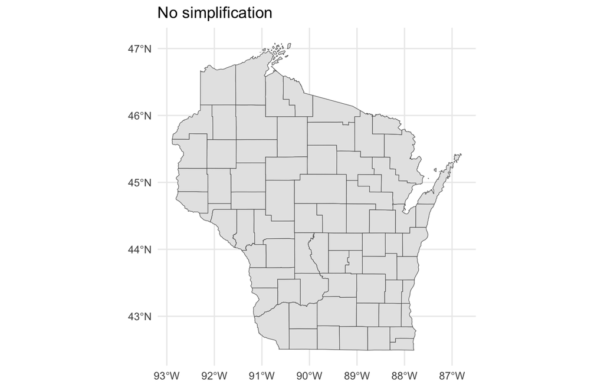

```r
# view county maps
  ggplot() +
    geom_sf(data = wi_counties) +
    labs(title = "No simplification") +
    theme_minimal()
```

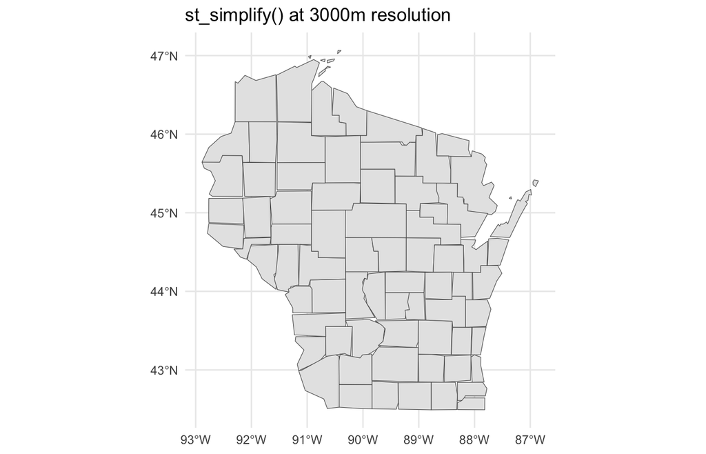

```r
# simplify 1: do not preserve topology
  counties_simple_st <- st_simplify(
    wi_counties, # shapefile to simplify
    dTolerance = 3e3) # resolution to 3000 meters

# plot
  ggplot() +
    geom_sf(data = counties_simple_st) +
    labs(title = "st_simplify() at 3000m resolution") +
    theme_minimal()
```

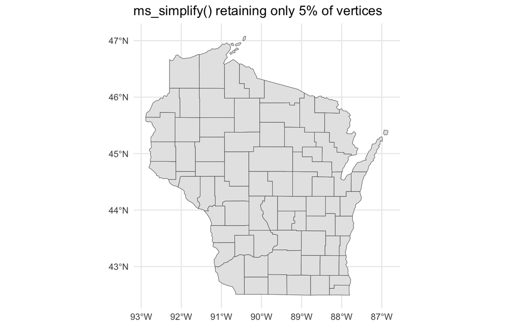

```r
# simplify 2: preserve topology
  counties_simple_ms <- ms_simplify(
    wi_counties, # sf object to simplify
    keep = 0.05, # proportion of vertices to retain
    snap = TRUE, # snap vertices at small distances to fix misallignment
    keep_shapes = TRUE) # prevent small shapes from disappearing (islands)

# plot
  ggplot() +
    geom_sf(data = counties_simple_ms) +
    labs(title = "ms_simplify() retaining only 5% of vertices") +
    theme_minimal()
```

```r
# view shapefile sizes
  object.size(wi_counties)
```

```
## 325760 bytes
```

```r
  object.size(counties_simple_st)
```

```
## 107176 bytes
```

```r
  object.size(counties_simple_ms)
```

```
## 107816 bytes
```

Notice the borders along lakes and rivers have smoothed dramatically in both simplified boundaries. But, the `st_simplify()` process left small gaps between counties, which can impact mapping aesthetics, as well as any spatial statistics. `ms_simplify()` retains boundaries. Both simplified shapefiles are 1/3 the total size of wi_counties. Simplification is very helpful for shapefiles with many rows of line, polygon, and multipolygon geometries.

**Example: repair broken or topologically impossible geometries.** Finally, We need to make sure that our geometries - the geometry variable for each row in our spatial data that describes the shape and location of the data - are topologically valid. You can use `st_is_valid` to confirm valid geometries. This function evaluates each geometry value for structural errors such as self-intersecting polygons, holes outside boundary lines, or an insufficient number of coordinate points. It returns a vector of TRUE or FALSE for each geometery. Invalid geometries will often cause geocomputation and mapping errors. If you a re having trouble with unknown errors, make sure your geometries are valid.

If your geometries are not valid, repair them with `st_make_valid()`. For large shapefiles, `st_make_valid()` can take a long time. Once you repair your geometries, be sure to save the repaired file as a master shapefile.

```r
# check to see if geometries are valid for each county.
# returns vector of Valid/not Valid Geometry
  st_is_valid(wi_counties, reason = TRUE)
```

```
##  [1] "Valid Geometry" "Valid Geometry" "Valid Geometry" "Valid Geometry"
##  [5] "Valid Geometry" "Valid Geometry" "Valid Geometry" "Valid Geometry"
##  [9] "Valid Geometry" "Valid Geometry" "Valid Geometry" "Valid Geometry"
## [13] "Valid Geometry" "Valid Geometry" "Valid Geometry" "Valid Geometry"
## [17] "Valid Geometry" "Valid Geometry" "Valid Geometry" "Valid Geometry"
## [21] "Valid Geometry" "Valid Geometry" "Valid Geometry" "Valid Geometry"
## [25] "Valid Geometry" "Valid Geometry" "Valid Geometry" "Valid Geometry"
## [29] "Valid Geometry" "Valid Geometry" "Valid Geometry" "Valid Geometry"
## [33] "Valid Geometry" "Valid Geometry" "Valid Geometry" "Valid Geometry"
## [37] "Valid Geometry" "Valid Geometry" "Valid Geometry" "Valid Geometry"
## [41] "Valid Geometry" "Valid Geometry" "Valid Geometry" "Valid Geometry"
## [45] "Valid Geometry" "Valid Geometry" "Valid Geometry" "Valid Geometry"
## [49] "Valid Geometry" "Valid Geometry" "Valid Geometry" "Valid Geometry"
## [53] "Valid Geometry" "Valid Geometry" "Valid Geometry" "Valid Geometry"
## [57] "Valid Geometry" "Valid Geometry" "Valid Geometry" "Valid Geometry"
## [61] "Valid Geometry" "Valid Geometry" "Valid Geometry" "Valid Geometry"
## [65] "Valid Geometry" "Valid Geometry" "Valid Geometry" "Valid Geometry"
## [69] "Valid Geometry" "Valid Geometry" "Valid Geometry" "Valid Geometry"
```

```r
# logical check for all all geometries in a shapefile.
# useful for shapfiles with lots of rows
  all((st_is_valid(wi_counties, reason = TRUE)) == "Valid Geometry")
```

```
## [1] TRUE
```

```r
# if any geomtries are not valid, repair
  wi_counties_valid <- st_make_valid(wi_counties)
```

## Best Practices for Spatial Data Workflows

### 1. Drop geometries for tabular data wrangling

If you are performing lots of data wrangling on tabular attribute data - say, with large, tract-level US Census or American Community Survey data - it is best to perform these functions on tibble, data.table, or other non-spatial R data object classes. The geometry column in a large sf class R object (large N of polygon or line data, specifically) dramatically slows down complicated tabular data wrangling processes. To avoid this, separate your tabular data from your geometries, and retain the linking geographic identifier column within each dataframe. Once you have completed data wrangling, you can append the geometries and sf class back to your tabular data using the linking identifier column.

An ideal way to do this is to duplicate your large sf object, `sf_data_object`, into a tabular data object using code like this: `tabular_data_object <- sf_data_object`.

Then, take the `sf_data_object` and keep only the geometry column and the spatially relevant variables (like geographic identifiers, land and water area, etc.). If your data is time series data in long format, then reduce the rows to just one per geometry. This new, master shapefile should be a much smaller sized shapefile with one entry per unique geometry, the geometry column, the geographic identifier variables like FIPS or GEOIDs, and any associated spatial variables.

Next, take the `tabular_data_object` to a data.frame object and retain just the tabular data and the geographic identifier. Drop the geometry column and other spatial variables. Perform all your tabular and non-spatial data wrangling on this data.frame object.

Once all your tabular data wrangling is complete, perform a `right_join()` to convert your data.frame back into a sf class R object with tract geometries.

This process can be implemented for any data or geographic scale, and is especially helpful for timeseries and large N survey data sets that have a LINE or POLYGON/MULTIPOLYGON geometry column. Just be sure to retain the correct linkage variable to re-associate your geometries to your attribute data.

### 2. Establish a master CRS for your project

As you import more and more shapefiles into your environment, be mindful of the CRS assigned to each. Shapefiles with different CRS metadata often produce software errors - or worse, hidden bad data! - when you interact them using spatial data operations and geometric operations. Avoid these issued by establishing one CRS for the entire project.

Determine the CRS that is most suitable for your analysis, and define it as an an object in your environment using code like this: `master_crs_object <- st_crs([sf object that has your preferred CRS])` .

Apply your master CRS to all your shapefiles once you import them using a command similar to this: `any_project_shapfile <- st_transform(any_project_shapefile, crs = master_crs_object)`

### 3. Simplify vector and line data

If you have shapefiles that are too finely generalized for your analysis, simplify them using `sf::st_simplify()` or `rmapshaper::ms_simplify()` functions. Recal that the `rmapshaper` package is “topographically aware”, meaning it will not create any gaps between shared boundaries of polygon or line geometries. `sf::st_simplify()` does not have this capability. If you simplify any shapefile, be sure to append the same set of simplified geometries back to any tabular data after tabular data wrangling.

### 4. Validate and repair geometries

Make sure that your shapefile geometries - the geometry variable for each row in our spatial data that describes the shape and location of the data - are topologically valid. Shapefiles from non-standardized sources (like user generated data, locally sourced shapefiles, etc.) often have errors in their geometries. Additionally, shapfiles that have undergone many geometric operations (like simplify, union, intersections, masking, and clipping) may also have topographical errors.

Use the `sf::st_is_valid()` command to confirm valid geometries. Use the `sf::st_make_valid()` command to repair any broken geometries in your shapefiles. If you repair a shapefile, be sure to append the same set of repaired geometries back to any tabular data after tabular data wrangling.

### 5. Use master shapefiles

If you are using lots of differnet data sets at different geographic levels, and for different years (say, counties and census tracts from 1990 to 2020) then it is best practice to have a master shapefile for each set of boundaries present in the data. Apply your `master_crs_object` to each master shapefile, and simplify your master shapefiles to the level of generalization needed for the project, and validate and repair each master shapefile.

Then, whenever you need to spatialize one of the tabular data sets, simply `right_join()` it with the correct geography. This way, you use a consistent CRS, and validated, simplified geometries for all your data sets, ensuring that any spatial data operations or geometric processing will run smoothly.

### 5. Keep your work space clean and tidy

Finally, remove objects from your environment that you no longer need in your analysis, or save larger objects and call them back in later. This keeps your space manageable, and saves working memory. The Primer for Spatial Data is complete, so let’s run a few housekeeping tasks to clean up.

```r
# remove R objects that are no longer needed
  rm(us_states, roads,
     wi, wi_counties,
     wi_airports, wi_roads, wi_10km,
     ash_bay_counties, my_special_crs_object,
     world_mercator, world_mollweide, world_ea, world_cust,
     temp, wi_airport_buffer, wi_counties_with_airport,
     wi_county_points1, wi_county_points2,
     counties_simple_st, counties_simple_ms, wi_counties_valid)

# use gc() to free space in working memory
  gc()
```

```
##           used  (Mb) gc trigger  (Mb) limit (Mb) max used  (Mb)
## Ncells 5734437 306.3   11995745 640.7         NA 11995745 640.7
## Vcells 9689525  74.0   30354092 231.6      24576 37778034 288.3
```

## Spatial Data Science Resources

- [**Geocomputation With R**](https://r.geocompx.org/) by Robin Lovelace, Jakub Nowosad, and Jannes Muenchow - comprehensive online resource on geographic data analysis, visualization, and modeling.
- [**Spatial Data Science**](https://r-spatial.org/book/) by Roger Bivand and Edzar Pebesma - comprehensive online resource on geographic data analysis, visualization, and modeling.
- [**Hands-on Spatial Data Science with R**](https://spatialanalysis.github.io/handsonspatialdata/index.html) by Luc Anselin, Grant Morrison, Angela Li, Karina Acosta - guide to spatial data handling, exploratory data analysis, spatial weights matrixes, and spatial statistics.
- [**Spatial Analysis with R**](https://chiajung-yeh.github.io/Spatial-Analysis/) by Chia Jung Yeh - comprehensive index of GIS concepts, spatial data operations, geometric operations, spatial data procedures, mapping, and geocomputation.
- [**Simple Features R Package (sf)**](https://r-spatial.github.io/sf/) - primary package for manipulating vector-based spatial data in R.
- [**TIGER/Line and cartographic boundary shapefiles ( R package tigris)**](https://cran.r-project.org/web/packages/tigris/refman/tigris.html#tigris) - R package to import a range of official US cartographic data.
- [**Sample data sets R Package (spData)**](https://jakubnowosad.com/spData/) - R package for example spatial data sets for practice.
- [**The R Graph Gallery**](https://r-graph-gallery.com/) - Help and inspiration for beautiful figures and maps made in R, with sample code and instruction.

# Part 3: Population and Survey Data -

With a basic foundation of spatial data types, coordinate reference systems, spatial processing, and spatial workflows, you now have the tools to integrate real-world social, health, and environmental data sets.

## Import and Investigate Survey Data

Let’s first import the example health survey data set and investigate the variables. Note that this data is not real. It is generated data that mirrors the structure of a multi-wave health survey. It is not a shapefile or a GIS ready data set, per se. It is intented to demonstrate how to use a-spatial, tabular survey data, any associated spatially relevant variables (FIPS codes, longitude/latitude), and GIS processing in R to make the survey data into a GIS ready format for integration with environmental data.

```r
# load provided survey data, survey_df
    load(here("data","clean","sample_survey","survey_data.RData"))

# view column names
    colnames(survey_df)
```

```
##  [1] "respondent_ID"   "sex"             "race"            "date_of_birth"
##  [5] "survey_wave"     "survey_date"     "asthma_severity" "hsp_30_days"
##  [9] "hsp_date"        "outcome_cont"    "GEOID"           "county_fips"
## [13] "tract_fips"      "geo_year"        "longitude"       "latitude"
```

```r
# view metadata
    class(survey_df)
```

```
## [1] "tbl_df"     "tbl"        "data.frame"
```

```r
    str(survey_df)
```

```
## tibble [3,000 × 16] (S3: tbl_df/tbl/data.frame)
##  $ respondent_ID  : chr [1:3000] "R0001" "R0001" "R0001" "R0002" ...
##  $ sex            : chr [1:3000] "Male" "Male" "Male" "Female" ...
##  $ race           : chr [1:3000] "Black" "Black" "Black" "White" ...
##  $ date_of_birth  : Date[1:3000], format: "1955-06-04" "1955-06-04" ...
##  $ survey_wave    : int [1:3000] 1 2 3 1 2 3 1 2 3 1 ...
##  $ survey_date    : Date[1:3000], format: "2015-09-29" "2018-09-12" ...
##  $ asthma_severity: Ord.factor w/ 4 levels "None"<"Mild"<..: 1 2 1 2 3 3 2 2 1 1 ...
##  $ hsp_30_days    : int [1:3000] 0 1 0 0 0 0 0 0 0 0 ...
##  $ hsp_date       : Date[1:3000], format: NA "2018-08-27" ...
##  $ outcome_cont   : num [1:3000] 32.6 48.9 48.4 48.9 40.8 ...
##  $ GEOID          : chr [1:3000] "55035000302" "55035000302" "55035000302" "55029100700" ...
##  $ county_fips    : chr [1:3000] "55035" "55035" "55035" "55029" ...
##  $ tract_fips     : chr [1:3000] "55035000302" "55035000302" "55035000302" "55029100700" ...
##  $ geo_year       : num [1:3000] 2010 2010 2010 2010 2010 2010 2010 2010 2010 2010 ...
##  $ longitude      : num [1:3000] -91.4 -91.4 -91.4 -87.3 -87.3 ...
##  $ latitude       : num [1:3000] 44.8 44.8 44.8 44.8 44.8 ...
```

You can further investigate the data by viewing it as a table by running `View(survey_df)` in the Console pane, or clicking on the object in the Environment pane. Beware of the View() command with very large data sets, especially spatial ones (100+ columns, 10,000+ rows, multi-polygon geometries)!

The survey data has some spatial identifiers. Lets see if we can map the data.

```r
# plot geometry
  ggplot() +
    geom_sf(data = survey_df) +
    theme_minimal()
```

```
## Error in `geom_sf()`:
## ! Problem while computing stat.
## ℹ Error occurred in the 1st layer.
## Caused by error in `compute_layer()`:
## ! `stat_sf()` requires the following missing aesthetics: geometry.
```

Oops an error! That was expected, as the survey data has tabular geographic identifier variables and lat/long variables, but no actual spatial geometries or metadata (class sf, assigned CRS, etc.). Looks like we will have to make some changes to the standard dataframe before we merge air quality data.

## Import and Investigate Population Data

Next, we import population level longitudinal data from the US Census Bureau’s American Community Survey. This data is formatted as a time series and is structured very similarly to many other population data products. We will use the [`tidycensus` package](https://walker-data.com/tidycensus/index.html) to access a US Census Bureau API and download data from the American Community Survey. You can get your own Census API key from https://api.census.gov/data/key_signup.html. First, let’s install our API key.

**BE SURE TO EDIT THE BELOW CODE WITH YOUR NEWLY GENERATED CENSUS API KEY!**

1. Replace the “paste your API key here” text with your new API key.
2. Remove the #hashtag in front of the `my_api_key <- c(...)` command.
3. Run the code chunk.

```r
# install census API
  #my_api_key <- c("paste your API Key here")
  #census_api_key(my_api_key)
```

**NOTE:** An alternative census data API is the `impumsr` package. `ipumsr` gives access to a range of useful IPUMS data sets. Specifically, the IPUMS National Historic Geographic Information System (NHGIS) data aggregated population data is useful for GIS purposes. These data have lots of decennial census time series data that is processed and harmonized to standard US Census geographic boundaries. [Learn about IPUMS here](https://www.ipums.org). Learn about NHGIS here. [Learn about `ipumsr` here](https://tech.popdata.org/ipumsr/index.html).

Next, we will use `tidycensus` to import aggregated ACS data. `tidycensus` can show you all the available variables for the decennial census, the ACS, and other useful data sets. Let’s look at the available 2020 ACS tables and variables by saving them to a data.frame and using the `View()` function in the console, or clicking the object in the “Environment” tab.

```r
# view available variables
  acs_2020 <- load_variables(2020, "acs5", cache = TRUE)
```

When viewing the dataframe, you can search for specific concepts at the top. The geography field indicates the lowest level of census geography that the variable is available.

```r
# import 2020
  my_df <- get_acs(geography = "tract",      # level of aggregation
                   state = "WI",             # restrict to certain state
                   year = 2020,              # year of data
                   variables = "B17020_002", # variable name (poverty status)
                   geometry = TRUE)          # include geometries
```

[output not shown]

[output not shown]

Great! We now have ACS data, and it is spatial! But, it is only for one year, at one level of geography, and for one variable. Let’s perform the same process, but over and over again using a `for` loop so we can make a time series data frame. The steps are:

1. Make your `for` loop helper objects, such as empty lists, vectors of variables, looping parameters, etc.
2. Run your `for` loop to import data for each year and level of geography.

The for loop will import, clean, and format ACS data for each year set in the parameters, and save each geog/year tabular data to a list of data frames. Saving data as lists can help with later processing, and is a memory efficient way to store larger data sets.

```r
# ---- Make loop objects ----
# make vector of variables
  acs_var_list <- c("B01003_001", # tot_pop
                    "B25064_001", # med_gross_rent
                    "B17020_002", # poverty status
                    "B19013_001") # med_hh_income

# make vector of desired years
  years <- c(2014:2023)

# make vector of desired geographies
  geographies <- c("county", "tract", "cbg")

# make vector of block group counties to reduce data size
  cbg_filter <- c("55027", "55131", "55089",
                  "55025", "55055", "55133", "55079",
                  "55105", "55127", "55101", "55059")

# make empty lists for each geography
  acs_county <- list()
  acs_tract <- list()
  acs_cbg <- list()

# ---- Run for loop ----
  for (g_i in geographies) { # for each geography level
    for (y_i in years) {     # and each year

    # values to name objects within loop iteration
      geog_value <- g_i
      year_value <- as.character(y_i)

    # pull data from API by year and geography
      temp <- get_acs(geography = g_i,
                      state = "WI",
                      year = y_i,
                      variables = acs_var_list,
                      geometry = FALSE)

    # make helper vars and geo identifiers
      temp <- temp |>
        mutate(county_fips = str_sub(GEOID, 1, 5)) |>
        mutate(geog_level = geog_value) |>
        mutate(year = y_i)

    # if cbg, then filter to certain counties
      temp <- temp |>
        filter(if (geog_value == "cbg") county_fips %in% cbg_filter else year > 0)

    # drop margin of error variable and long name
      temp <- temp |>
        dplyr::select(-c(moe, NAME))

    # pivot wider
      temp <- temp |>
        tidyr::pivot_wider(names_from = variable, values_from = estimate)

    # rename ACS table vars
      temp <- temp |>
        rename(tot_pop = B01003_001,
               med_gross_rent = B25064_001,
               pov_status = B17020_002,
               med_hh_income = B19013_001)

      # append data to correct list based on geography
      if (geog_value == "county") acs_county[[paste0(geog_value,"_",year_value)]] <- temp
      if (geog_value == "tract") acs_tract[[paste0(geog_value,"_",year_value)]] <- temp
      if (geog_value == "cbg") acs_cbg[[paste0(geog_value,"_",year_value)]] <- temp

    # clean up environment
      rm(geog_value, year_value)
    }}

# ---- Clean up Environment ----
  rm(temp, acs_2020, g_i, y_i, geographies, years, acs_var_list)
```

```r
# view column names
  str(acs_county[["county_2014"]])
```

```
## tibble [72 × 8] (S3: tbl_df/tbl/data.frame)
##  $ GEOID         : chr [1:72] "55001" "55003" "55005" "55007" ...
##  $ county_fips   : chr [1:72] "55001" "55003" "55005" "55007" ...
##  $ geog_level    : chr [1:72] "county" "county" "county" "county" ...
##  $ year          : int [1:72] 2014 2014 2014 2014 2014 2014 2014 2014 2014 2014 ...
##  $ tot_pop       : num [1:72] 20604 16065 45718 15064 252698 ...
##  $ pov_status    : num [1:72] 2446 2618 6002 1914 28682 ...
##  $ med_hh_income : num [1:72] 45366 39172 44709 45158 53254 ...
##  $ med_gross_rent: num [1:72] 718 588 642 563 708 638 645 678 710 585 ...
```

```r
  str(acs_tract[["tract_2018"]])
```

```
## tibble [1,409 × 8] (S3: tbl_df/tbl/data.frame)
##  $ GEOID         : chr [1:1409] "55001950100" "55001950201" "55001950202" "55001950400" ...
##  $ county_fips   : chr [1:1409] "55001" "55001" "55001" "55001" ...
##  $ geog_level    : chr [1:1409] "tract" "tract" "tract" "tract" ...
##  $ year          : int [1:1409] 2018 2018 2018 2018 2018 2018 2018 2018 2018 2018 ...
##  $ tot_pop       : num [1:1409] 2870 1244 2599 4533 1603 ...
##  $ pov_status    : num [1:1409] 248 172 436 896 312 436 294 429 262 295 ...
##  $ med_hh_income : num [1:1409] 55481 41853 38345 35410 33315 ...
##  $ med_gross_rent: num [1:1409] 834 654 676 589 785 898 891 331 616 684 ...
```

We imported tabular attribute data in this loop because the geometry columns in sf R objects can be quite large, especially for timeseries data. To get shapefiles for the analysis, we will instead import master shapefiles in a later step. Once we import and process the various years and geographic levels of population data in its tabular attribute form, we will merge it with spatial geometries from master shapefiles and and convert it to a sf R object.

*Note:* Geographic boundaries often change over time. New counties are carved out of existing ones. Census tracts are dissolved together or split apart. This is tricky business with spatially designated timeseries data. The NHGIS data from IPUMS is *one option* for getting longitudinal data that is harmonized to consistent boundaries. But, NHGIS data is often limited to commonly used decennial variables. In practice, harmonizing your data and geographic boundaries is tough work. For today, we are sticking with a time span that uses the same boundaries. Future workshops may address the issue of boundary changes…

## Import Master Shapefiles

The next step is to import the geographic boundary files that you will apply to all of your spatial data. We will run some diagnostics on the shapefiles to make sure they are suitable for the project, we will simplify them to the appropriate level of cartographic generalization, and validate and repair any topological errors in the geometry columns. We will import shapefiles from tidycensus.

### Investigate master shapefiles

Let’s look at the shapefile metadata for our geographic boundaries.

```r
# confirm all CRS are the same for all shapefiles
  st_crs(sf_county_2010) == st_crs(sf_tract_2010)
```

```
## [1] TRUE
```

```r
  st_crs(sf_county_2010) == st_crs(sf_cbg_2010)
```

```
## [1] TRUE
```

```r
  st_crs(sf_tract_2010) == st_crs(sf_cbg_2010)
```

```
## [1] TRUE
```

```r
# view CRS metadata
  st_crs(sf_county_2010)
```

```
## Coordinate Reference System:
##   User input: NAD83
##   wkt:
## GEOGCRS["NAD83",
##     DATUM["North American Datum 1983",
##         ELLIPSOID["GRS 1980",6378137,298.257222101,
##             LENGTHUNIT["metre",1]]],
##     PRIMEM["Greenwich",0,
##         ANGLEUNIT["degree",0.0174532925199433]],
##     CS[ellipsoidal,2],
##         AXIS["latitude",north,
##             ORDER[1],
##             ANGLEUNIT["degree",0.0174532925199433]],
##         AXIS["longitude",east,
##             ORDER[2],
##             ANGLEUNIT["degree",0.0174532925199433]],
##     ID["EPSG",4269]]
```

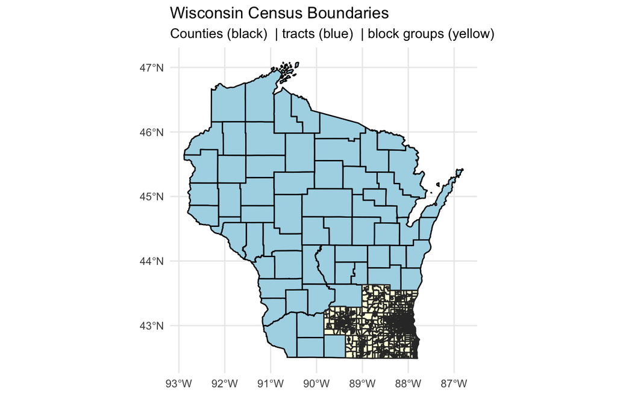

```r
# map each level of geography
  ggplot() +
    geom_sf(data = sf_tract_2010,
            color = "royalblue") +
    geom_sf(data = sf_county_2010,
            color = "black",
            fill = "lightblue",
            linewidth = 0.5) +
    geom_sf(data = sf_cbg_2010,
            color = "gray20",
            fill = "lightyellow",
            linewidth = 0.5) +
    labs(title = "Wisconsin Census Boundaries",
         subtitle = "Counties (black)  | tracts (blue)  | block groups (yellow)") +
    theme_minimal()
```

### Establish a master CRS for this project

```r
# set project CRS
  master_crs <- st_crs(sf_county_2010)
```

### Simplify vector and line data

`tidycensus` has [lots of options](https://walker-data.com/tidycensus/articles/spatial-data.html) for which types of shapefiles to import and how detailed thier cartographic generalization is. Our county, tract, and blockgroup geometries could use a bit of simplifying. We will us `rmapshaper` to retain boundaries and other topological features of the data.

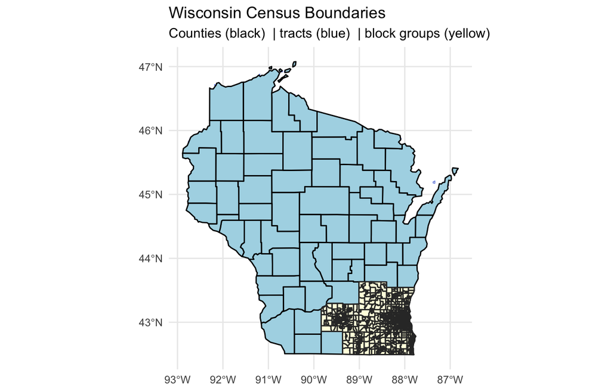

```r
# simplify county
  sf_county_2010 <- ms_simplify(
    sf_county_2010, # sf object to simplify
    keep = 0.05, # proportion of vertices to retain
    snap = TRUE, # snap vertices at small distances to fix misallignment
    keep_shapes = TRUE) # prevent small shapes from disappearing (islands)

# simplify tract
  sf_tract_2010 <- ms_simplify(
    sf_tract_2010, # sf object to simplify
    keep = 0.05, # proportion of vertices to retain
    snap = TRUE, # snap vertices at small distances to fix misallignment
    keep_shapes = TRUE) # prevent small shapes from disappearing (islands)

# simplify cbg
  sf_cbg_2010 <- ms_simplify(
    sf_cbg_2010, # sf object to simplify
    keep = 0.05, # proportion of vertices to retain
    snap = TRUE, # snap vertices at small distances to fix misallignment
    keep_shapes = TRUE) # prevent small shapes from disappearing (islands)

# map simplified geometries
  ggplot() +
    geom_sf(data = sf_tract_2010,
            color = "royalblue") +
    geom_sf(data = sf_county_2010,
            color = "black",
            fill = "lightblue",
            linewidth = 0.5) +
    geom_sf(data = sf_cbg_2010,
            color = "gray20",
            fill = "lightyellow",
            linewidth = 0.5) +
    labs(title = "Wisconsin Census Boundaries",
         subtitle = "Counties (black)  | tracts (blue)  | block groups (yellow)") +
    theme_minimal()
```

The resulting map is still legible, and the boundaries plot much better along rivers and coastlines.

### Repair and validate geometries

To round out our spatial data management and best practices, we will ensure that our geometries are valid and repair them if they are not.

```r
# check to see if each geometry value in sf_county_2010 is valid
  st_is_valid(sf_county_2010, reason = TRUE)
```

```
##  [1] "Valid Geometry" "Valid Geometry" "Valid Geometry" "Valid Geometry"
##  [5] "Valid Geometry" "Valid Geometry" "Valid Geometry" "Valid Geometry"
##  [9] "Valid Geometry" "Valid Geometry" "Valid Geometry" "Valid Geometry"
## [13] "Valid Geometry" "Valid Geometry" "Valid Geometry" "Valid Geometry"
## [17] "Valid Geometry" "Valid Geometry" "Valid Geometry" "Valid Geometry"
## [21] "Valid Geometry" "Valid Geometry" "Valid Geometry" "Valid Geometry"
## [25] "Valid Geometry" "Valid Geometry" "Valid Geometry" "Valid Geometry"
## [29] "Valid Geometry" "Valid Geometry" "Valid Geometry" "Valid Geometry"
## [33] "Valid Geometry" "Valid Geometry" "Valid Geometry" "Valid Geometry"
## [37] "Valid Geometry" "Valid Geometry" "Valid Geometry" "Valid Geometry"
## [41] "Valid Geometry" "Valid Geometry" "Valid Geometry" "Valid Geometry"
## [45] "Valid Geometry" "Valid Geometry" "Valid Geometry" "Valid Geometry"
## [49] "Valid Geometry" "Valid Geometry" "Valid Geometry" "Valid Geometry"
## [53] "Valid Geometry" "Valid Geometry" "Valid Geometry" "Valid Geometry"
## [57] "Valid Geometry" "Valid Geometry" "Valid Geometry" "Valid Geometry"
## [61] "Valid Geometry" "Valid Geometry" "Valid Geometry" "Valid Geometry"
## [65] "Valid Geometry" "Valid Geometry" "Valid Geometry" "Valid Geometry"
## [69] "Valid Geometry" "Valid Geometry" "Valid Geometry" "Valid Geometry"
```

```r
# logical check that every geometry value validation is "Valid Geometry"
# avoids masive console output
  all((st_is_valid(sf_county_2010, reason = TRUE)) == "Valid Geometry")
```

```
## [1] TRUE
```

```r
  all((st_is_valid(sf_tract_2010, reason = TRUE)) == "Valid Geometry")
```

```
## [1] TRUE
```

```r
  all((st_is_valid(sf_cbg_2010, reason = TRUE)) == "Valid Geometry")
```

```
## [1] TRUE
```

Looks good! Moving forward!

*Note:* Geometries can be corrupted after lots of geometry operations, such as joins, masking, overlaps, etc. If you are doing these types of activities, it is a good idea to check for valid geometries often. Also, shapefiles from non-standard sources may have issues with their metadata and geometries, so always check these things out upon import.

# Part 4: Gridded Smoke Data -

[The Environmental Change and Human Outcomes Lab](https://www.stanfordecholab.com/data) at Stanford produced [daily estimates of smoke-attributable PM2.5](https://www.stanfordecholab.com/wildfire_smoke) at the county, tract, ZCTA, and 10km grid levels. The data spans 2006 to 2023. They estimated these values by processing very high-frequency raster-based air quality data from the [United States high-frequency PM2.5 air quality data set](https://zenodo.org/records/7884640), and computing the difference between “expected” background PM2.5 pollution, and observed PM2.5 measured by stationary sensors during known fire and smoke events. ECHOLab defined smoke events using smoke plume polygon shapefiles from the [NOAA Hazard Mapping System](https://www.ospo.noaa.gov/products/land/hms.html#data). See ECHOLab’s [methodological details here](https://web.stanford.edu/~mburke/papers/ChildsEtAl2022_smoke.pdf).

This is a great and easy-to-use data product because it comes in a pre-processed, vector format. ECHOLab estimated smoke-derived PM2.5, and also performed the challenging raster-to-vector GIS processing to aggregate daily estimates for useful spatial units. Using each of the 10km, tract, and county estimates, we can more easily append wildfire-related air pollution to our population and survey data.

### Download ECHOLab Data

1. Navigate to the ECHOLab [county data dropbox data repository](https://www.dropbox.com/scl/fo/91k0aq80vp57qixkm508q/AOADXrl5470J9uGaxpkOniA/county?dl=0&rlkey=nutebc9pn2vsupr0p9ks4k73u&subfolder_nav_tracking=1). Download the .rds file titled “smokePM2pt5_predictions_daily_county_20060101-20231231.rds”. Save it in data folder.: data/raw/echolab.
2. Navigate to the ECHOLab [tract data dropbox data repository](https://www.dropbox.com/scl/fo/91k0aq80vp57qixkm508q/AIRVst386qB2G_N1XhnE4qk/tract?dl=0&rlkey=nutebc9pn2vsupr0p9ks4k73u&subfolder_nav_tracking=1). Download the .rds file titled “smokePM2pt5_predictions_daily_tract_20060101-20231231.rds”. Save it in data folder.
3. Navigate to the ECHOLab [10km grid dropbox data repository](https://www.dropbox.com/scl/fo/91k0aq80vp57qixkm508q/AFwRS_BfKyaayrr9J1mU0PY/10km_grid?dl=0&rlkey=nutebc9pn2vsupr0p9ks4k73u&subfolder_nav_tracking=1). Download the .rds file titled “smokePM2pt5_predictions_daily_10km_20060101-20231231.rds”. Save it in data folder.
4. Navigate to the ECHOLab [10km grid dropbox data repository](https://www.dropbox.com/scl/fo/91k0aq80vp57qixkm508q/AFwRS_BfKyaayrr9J1mU0PY/10km_grid?dl=0&rlkey=nutebc9pn2vsupr0p9ks4k73u&subfolder_nav_tracking=1). Download the *entire folder* titled “10km_grid_wgs84”. Save the folder and its contents in the data folder. If it is zipped, unzip it.

### File paths and study parameters

Next, let’s define the file paths to the ECHOLab data and set the space/time parameters for the our study. We will make a list of dates that define every day that we want to import smoke data. We include December 2013 so we can calculate running 30 day averages for the first month of 2014. We also will define the study start and end dates, and define vector lists of county FIPS and tract FIPS for our study area (just Wisconsin boundaries).

```r
# write filepaths to smoke data
  echo_10km_path <- here("data",
                         "smokePM2pt5_predictions_daily_10km_20060101-20231231.rds")

  echo_10km_grid <- here("data", "10km_grid_wgs84", "10km_grid_wgs84.shp")

  echo_county_path <- here("data",
                           "smokePM2pt5_predictions_daily_county_20060101-20231231.rds")

  echo_tract_path <- here("data",
                          "smokePM2pt5_predictions_daily_tract_20060101-20231231.rds")

# prepare analysis parameters
  all_dates = seq.Date(ymd("2013-12-01"), ymd("2023-12-31"), by = "day")

  start_date <- ymd("2013-12-01")
  end_date   <- ymd("2023-12-31")

  study_counties <- sf_county_2010$GEOID
  study_tracts <- sf_tract_2010$GEOID
```

### Import pre-processed county and tract PM2.5 data

Let’s start by importing the pre-processed ECHOLab data for counties and tracts. We will run a script that imports the data for the entire US and filters it to our study date range and spatial extent. Data processing steps include:

1. Read in the tabular RDS file for county and tracts.
2. Filter out any dates before or after the start of our study period.
3. Reduce the spatial extent of the data to just counties and tracts in Wisconsin.

We do not need to do any spatial data operations at this point because the tabular data from ECHOLab has county and tract identifiers as variables. So, we can simply filter out any county and tract not in our defined `study_counties` and `study_tracts` vectors. Note that the script often uses the garbage collection `gc()` command. It is helpful to perform this after you filter large amounts of data, as R will still store filtered cases in background working memory.

```r
# ---- County data ----
# Load smokePM2.5 predictions on smoke days
  smoke_county <- readRDS(echo_county_path)
  str(smoke_county)

# filter raw data to only years needed
  smoke_county <- smoke_county |>
    filter(date %within% interval(start_date, end_date))
  gc()

# filter to only counties in WI using FIPS codes
  smoke_county <- smoke_county |>
    filter(GEOID %in% study_counties)
  gc()

# ---- Tract data ----
# Load smokePM2.5 predictions on smoke days
  smoke_tract <- readRDS(echo_tract_path)
  str(smoke_tract)

# filter raw data to only years needed
  smoke_tract <- smoke_tract |>
    filter(date %within% interval(start_date, end_date))
  gc()

# filter to only tracts in WI using FIPS codes
  smoke_tract <- smoke_tract |>
    filter(GEOID %in% study_tracts)
  gc()
```

The ECHOLab data does not keep a record for days when smoke-derived PM2.5 is zero. So, we have to do some data wrangling to generate records for these days in the tract and county data sets. We can do this by “crossing” the list of counties or tracts with the list of each date from 2014 to 2023. This generates a blank data frame where each row is defined by unique date/FIPS combination with every date in the study period.

Then we will `left_join()` the ECHOLab data to this date/FIPS dataframe, joined by the geographic identifier and the date variables. For days without smoke-derived PM2.5 we simply mutate the smoke variable from NA to 0.

```r
# ---- Generate county smoke data for all dates ----
# get full combination of county/dates with expand.grid()
# Warning: this may require a large amount of memory with multiple years and states
  county_days = expand.grid(GEOID = study_counties, date = all_dates)

# Match smoke predictions on smoke days to county/date
  smoke_county = left_join(county_days, smoke_county, by = c("GEOID", "date"))

# Predict 0 for NA county/date days, which are non-smoke days
  smoke_county = mutate(smoke_county, smokePM_pred = replace_na(smokePM_pred, 0))

# clean environment
  rm(county_days)
  gc()

# ---- Generate tract smoke data for all dates ----
# get full combination of tract/dates
# warning: this may require a large amount of memory if multiple years and states
  tract_days = expand.grid(GEOID = study_tracts, date = all_dates)

# Match smoke predictions on smoke days to tract/date
  smoke_tract = left_join(tract_days, smoke_tract, by = c("GEOID", "date"))

# Predict 0 for NA tract/date days, which are non-smoke days
  smoke_tract = mutate(smoke_tract, smokePM_pred = replace_na(smokePM_pred, 0))

# clean environment
  rm(tract_days)
  gc()
```

At this stage, we have comprehensive, county- and tract-level tabular data on daily smoke derived PM2.5 smoke for the state of Wisconsin.